# Derecho Procesal

Lucas Fernandez

# 1. Derecho Procesal

- concepto

  aquella rama del derecho que estudia la organización de los TRB, señala sus atribuciones y competencias y determina las normas de procedimiento a que deben someterse tanto los TRB como las personas que concurren ante ellos planteando pretensiones procesales.
- contenido
  - orgánico

  es aquella rama del derecho procesal que comprende el estudio de la organización de los TRB de justicia y de sus atribuciones y competencia
  - funcional

  es aquella rama del derecho procesal que estudia las normas de procedimiento a que deben someterse tanto los TRB como las personas que concurren ante ellos planteando pretensiones procesales.
- características
  1. derecho público
  2. formal (forma, modo de realizar la actividad)
  3. autónomo y no adjetivo (tiene sus propios ppios, normas, instituciones)
  4. normas instrumentales (es el medio para lograr el restablecimiento o creación de un orden jurídico vulnerado) jurisdicción = realización práctica de las normas substantivas.
- fuentes
  1. directas = CPR, ley procesal, AA, TI
  2. indirectas = dº histórico, dº extranjero, jurisprudencia, doctrina, usos, costumbre y equidad.
- Vigencia
  - en cuanto al tiempo
    - Dictada una ley procesal ella rige de inmediato para todos los juicios que van a iniciarse y también para los que ya están en tramitación. Conforme a la jurisprudencia, la ley procesal rige inmediatamente (in actum).
    - Nunca una ley procesal puede afectar un juicio ya terminado y en el cual se ha dictado sentencia que se encuentre firme o ejecutoriada.
    - Los plazos que hubieren empezado a correr y las actuaciones y diligencias que ya estuvieren iniciadas se rigen se rigen por la ley vigente al tiempo de su iniciación
    - los actos o contratos válidamente celebrados bajo el imperio de una ley pueden probarse bajo el imperio de otra con los medios que aquéllas establecen para su justificación, pero la forma de rendirla está subordinada a la ley vigente en el tiempo que se rinda
  - en cuanto al espacio
    - art. 14 CC ppio de territorialidad, que se refleja en el aforismo *lex locus regit actum* que rigen las siguientes normas:
      - organización y atribuciones de los TRB de justicia
      - competencia de los TRB
      - normas relativas a los procedimientos contenciosos o no
      - respecto a los medios de prueba
      - respecto a la ejecución de las resoluciones dictadas por TRB nacionales.
    - excepciones a este ppio:
      - normas procesales internacionales, como aquellas sobre la tramitación de exhortos internacionales, cumplimiento de sentencias extranjeras, y sobre la extradición.
      - las señaladas en el art. 6 del COT

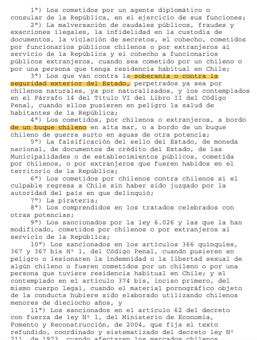

# 2. Jurisdicción

- concepto

  Couture: es la función pública realizada por órganos competentes del Estado con las formas requeridas por la ley en virtud de la cual por acto de juicio se determina el derecho de las partes, con el objeto de dirimir sus conflicto, controversias de relevancia jurídica mediante decisiones con autoridad de cosa juzgada eventualmente factible de ejecución

  Se dice que es factible de ejecución porque en un juicio no sólo interesa obbbtener una declaración favorable, sino que, el vencido cumpla con la prestación a que ha sudo condenado.
- Jurisdicción en la legislación:

  art. 76 CPR “la facultad de conocer de las causas civiles y criminales, de resolverlas y de hacer ejecutar lo juzgado, pertenece exclusivamente a los TRB establecidos por la ley”

  art. 1 COT “la facultad de conocer la causas civiles y criminales, de juzgarlas y de hacer ejecutar lo juzgado pertenece exclusivamente a los TRB que establece la ley”
- características
  1. origen constitucional
  2. unidad conceptual
  3. inderogable (por eso es nulo por objeto ilícito el de someterse a jurisdicción extranjera art. 1462)
  4. indelegable
  5. irrenunciable
  6. improrrogable
  7. territorial
  8. produce efecto de cosa juzgada
  9. está amparada por el imperio
- Momentos Jurisdiccionales:
  - *Notio*:

    El TRB toma en conocimiento de las pretensiones de las partes y de sus defensas, además de las pruebas aportadas.
  - *Decisio*:

    TRB resuelve la contienda jurídica lo que se efectúa a través de la sentencia.

    Las sentencias contienen tres partes:
    - *parte expositiva*: se individualiza las partes y se consignan sus alegaciones
    - *parte considerativa*: se efectúa los razonamientos y análisis de las alegaciones y de la prueba rendida
    - *parte resolutiva*: se señala la decisión del asunto controvertido
  - *Executio*:

    Se lleva a efecto el cumplimiento de lo resuelto utilizando, si fuera necesario, la fuerza para ello, denominado imperio. Cumplimiento es un concepto amplio que implica llevar a cabo lo dispuesto en la sentencia en la forma que disponga la ley. Ejecutar, se refiere a la ejecución forzada.
- equivalentes jurisdiccionales
  - conciliación

  es aquella en que se logra la solución de un conflicto entre las partes mediante un acuerdo de ellas, obtenido en un proceso con la participación activa del juez.
  - avenimiento

  se diferencia de la conciliación en que éste se obtiene extrajudicialmente, sin intervención alguna de un juez el que toma conocimiento del mismo a través de una presentación de las partes.
  - transacción

  es un contrato por el cual las partes ponen término extrajudicialmente a un litigio pendiente o precaven un litigio eventual, efectuando concesiones recíprocas. Para que valga como título ejecutivo se requiere que esta esté colocada en una escritura pública.
  - sobreseimiento definitivo

  es aquel en que se pone término al procedimiento penal, liberando al imputado de la responsabilidad del hecho atribuido, con autoridad de cosa juzgada.
  - sentencia extranjera

  en los casos que la ley le da valor por cuanto reemplaza la sentencia que podría haberse dictado en el país a través del procedimiento denominado exequátur.
- Lo Contencioso Administrativo

  Son todos aquellos conflictos que surgen entre un particular cualquiera y la Administración del Estado a consecuencia de algún acto administrativo.

# 3. Actos Judiciales no Contenciosos y Atribuciones Conexas

- Actos Judiciales no Contenciosos

  Lo primero que hay que decir, es que no existe una “Jurisdicción No Contenciosa”, sino que la ley exige que determinados actos requieren de la intervención de un juez y en los cuales no se promueven conflicto. Es por eso que se dice que se tratan más de una naturaleza administrativa.
- ¿Cuales son las Atribuciones Conexas ?

  Son las que señala el art. 3 del COT en los siguientes términos: “Los TRB tienen, además, las facultades *conservadoras, disciplinarias y económicas* que a cada uno de ellos se asignan en los en los respectivos títulos de este Código”
- Qué es la Facultad Conservadora?

  Consiste en una facultad no jurisdiccional que tiene por objeto mantener incólume (sin menoscabo o lesión) el principio constitucional en cuya virtud los **órganos estatales no deben rebasar los límites de la actividad que la CPR y las leyes le han asignado**.
  - Qué asuntos quedan comprendidos dentro de la Facultad Conservadora?
    1. El Recurso de Amparo art. 19 Nª 7 y 21 CPR
    2. El Recurso de Protección art. 20 CPR
    3. La institución del Privilegio de Pobreza, la cual tiene su fundamento en la garantía señalada en el art. 19 Nª 2 CPR
    4. Las Visitas que deben realizar los JG a establecimientos penitenciarios, en forma semanal o semestral art. 567 y ss. COT
- Qué es la Facultad Disciplinaria?

  Consisten en facultades para mantener la compostura en los debates judiciales y en el normal funcionamiento de los órganos que componen el Poder Judicial.
- Qué es la Facultad Económica?

  Consiste en medidas de orden general que buscan la correcta administración de justicia y se manifiesta a través de los Autos Acordados que dictan los TRB superiores que pueden ser de aplicación general reglando situaciones específicas.

# 4. Órganos Jurisdiccionales

- Bases de la Administración de Justicia
  - Ppio de Legalidad
    - la organización y atribuciones de los órganos jurisdiccionales debe estar fijado por ley = art. 76 CPR, art. 1 COT
    - los órganos jurisdiccionales deben observar rigurosamente las leyes procesales, ya que la sentencia debe fundarse en un proceso previo legalmente tramitado
  - Ppio de Territorialidad

    art. 7 COT los TRB sólo ejercen su potestad en los negocios y dentro del territorio que la ley les hubiere respectivamente asignado
  - Ppio de Independencia

    art. 12 COT El poder judicial es independiente de toda otra autoridad en el ejercicio de sus funciones.

    art. 7 y 76 CPR, 222 CP, 4 COT.
  - Ppio de Jerarquía

    El sistema de administración de justicia debe ser aplicado por diversos órganos jurisdiccionales ordenados jerárquicamente, en una estructura piramidal, para distribuir la competencia y permitir que los juicios sean fallados a lo menos por dos TRB. Se encuentra vinculado con un sistema de recursos de doble instancia.
  - Ppio de Publicidad

    art. 9 COT Los actos de los TRB son públicos, salvo las excepciones expresamente establecidas por la ley
  - Ppio de Pasividad

    art. 10 Los TRB no podrán ejercer su ministerio sino a petición de parte, salvo los casos en que la ley los faculte para proceder de oficio
  - Ppio de Inamovilidad

    art. 80 CPR Privilegio o garantía consagrado en beneficio de los magistrados judiciales. Tiene las ss. excepciones: - en caso de delitos - mal comportamiento - causales de orden constitucional
  - Ppio de la Inexcusabilidad

    art. 10 COT una vez reclamada su intervención en forma legal y en negocios de su competencia, no podrán excusarse de ejercer su autoridad ni aun por falta de ley que resuelva la contienda sometida a su decisión.

    Son excepciones: la incompetencia por causales de implicancia y recusación, o la acumulación.
  - Ppio de Responsabilidad

    art. 79 CPR y 13 COT, los jueces son personalmente responsables por los delitos de cohecho, falta de observancia en materia sustancial de las leyes que reglan el procedimiento, denegación y torcida administración de justicia u toda prevaricación en el desempeño de sus funciones.
- Qué se entiende por Órgano Jurisdiccional?

  Son órganos públicos, que realizan la función de jurisdicción, es decir, la de resolver litigios con eficacia de cosa juzgada y eventual posibilidad de ejecución, sin perjuicio de los demás actos no jurisdiccionales que la ley pueda encomendar a ellos, como seria el caso de las atribuciones conexas y los actos judiciales no contenciosos.
- Cómo se clasifican los TRB de acuerdo a su materia art. 5 COT?
  - En TRB ordinarios

  La CS, las CA, el Presidente de la CS, el Presidente de la CA de Santiago, un Ministro de CA, los TRB de JO en lo penal, los Jueces de Letras y los JG.
  - TRB especiales que forman parte del Poder Judicial
  1. los Juzgados de Familia
  2. los Juzgados de Letras del Trabajo
  3. los Juzgados de Cobranza Laboral y Previsional
  4. los TRB Militares en tiempo de Paz
  - Estos TRB se rigen por cuales normas?

    Se rigen por sus propias leyes sobre atribuciones y organización ley 19.968, Código del Trabajo, en el Código de Justicia Militar y en sus leyes complementarias. Las normas del COT solo se aplicarán a ellos cuando los cuerpos legales citados se remitan expresamente a él. Así por ejemplo art. 1 de la 19.968 que crean los TRB de familia señala que en lo no previsto en ella se rige por las normas del COT.
  - TRB especiales que no forman parte del Poder Judicial
  1. Juzgado de Policía Local
  2. TC
  3. Contraloría General de la República
  4. El Senado
  5. Director del SII
  - Estos TRB se rigen por cuales normas?

    Se rigen por sus propias leyes especiales, sin perjuicio de quedar sujetos a las disposiciones generales del COT.
  - TRB Arbitrales

  Son aquellos jueces nombrados por las partes, o por la autoridad judicial en subsidio, para la resolución de un asunto litigioso. Art. 222 COT
- Cómo se clasifican los TRB según número de jueces?

  Unipersonales, con la alocución “Juez”

  Colegiados, con la alocución “TRB”
- Qué son los TRB de derecho y los TRB de equidad?

  Se clasifican en TRB de derecho aquellos que en sus fallos deben ajustarse a derecho y los TRB de equidad son aquellos que se deben ajustar al principio de equidad, como sería el caso de los Arbitros Arbitradores.
- (?103-1) Qué son los TRB de instrucción y TRB sentenciadores?

  Se clasifican así considerando la fase del procedimiento en que despliegan su actividad.
- Como se clasifican en consideración a su jerarquía?
  1. En TRB superiores: CS, las CA, la Corte Marcial y la Corte Naval.
  2. TRB inferiores: los demás.
- Como se clasifican los jueces según el tiempo que dura su función?

  En Jueces Permanentes o Perpetuos y Jueces Temporales
- Qué son los TRB comunes y los TRB accidentales o unipersonales de excepción?

  Se llaman accidentales o de excepción aquellos que se constituyen para conocer causas en razón de la materia o del fuero de las personas, por jueces que pertenecen a ciertos TRB superiores.

  Son: El Presidente de la CS, el Presidente de la CA de Santiago y los Ministros de Corte de CA.
  - Cuales asuntos conocen los TRB unipersonales de excepción?
  - Un Ministro de CA conoce en 1ª instancia (Fuero Mayor):
    1. De las causas civiles en que sean parte o tengan interés las autoridades señaladas en el art. 50 COT.
    2. De las demandas civiles que se entablen contra los Jueces de Letras para hacer efectiva la responsabilidad civil resultante del ejercicio de sus funciones ministeriales.
    3. Demás casos que señale la ley.
  - El Presidente de la CA de Santiago conoce en 1ª instancia:
    1. Las causas de amovilidad de los ministros de la CS
    2. Las demandas civiles que se entablen contra uno o más miembros de la CS o Fiscal Judicial para hacer efectiva su responsabilidad por actos cometidos en el desempeño de sus funciones .
  - Un Ministro de la CS conoce en 1ª instancia:
    1. De las causas que se refiere el art. 23 de la Ley 12.033 (Exportación y comercio del salitre).
    2. De los delitos de jurisdicción de los TRB chilenos cuando puedan afectar las relaciones internacionales de la Republica con otro Estado.
    3. De la extradición pasiva (caso estudiante japonesa)
    4. De los demás asuntos que le encomiende las leyes.
  - El Presidente de la CS conoce en 1ª instancia:
    1. Las causas sobre amovilidad de los Ministros de las CA
    2. De las demandas civiles que se entablen contra uno o más miembros o fiscal judicial de las CA para hacer efectiva la responsabilidad por actos cometidos en el desempeño de sus funciones
    3. De las causas de presas y demás que deban juzgarse con arreglo al Derecho Internacional
    4. De los demás asuntos que otras leyes entreguen a su conocimiento.
- Jueces en visita extraordinario

  art. 50 un ministro de la CA respectiva según turno conocerá en 1ª instancia, 5º, de los demás asuntos que otras leyes le encomienden.
  - art. 560 TRB ordenará especialmente visitas cuando
  1. causas civiles que puedan afectar las relaciones internacionales
  2. investigación de hechos o delitos cuyo conocimiento corresponda a la justicia militar, que puedan afectar las relaciones internacionales, produzcan alarma pública y exijan pronta represión por su gravedad y perjudiciales consecuencias
  3. siempre que sea necesario investigar hechos que afecten la conducta de los jueces en el ejercicio de sus funciones y cuando hubiere retardo notable en el despacho de los asuntos sometidos al conocimiento de dichos jueces

## 4.1. Estudio Particular de los TRB Ordinarios

- Juzgados de Garantía

  Es el juez encargado de decidir sobre la procedencia de todas las actuaciones que puedan afectar los derechos esenciales de las personas que puedan derivarse de una actuación de la investigación penal, como aquellas medidas cautelares que puedan afectar al imputado.

  Además, dicta sentencia en los procedimientos abreviados, simplificados, monitorio y en el de acción penal privada.
  - como están conformados?

  Por uno o más jueces con competencia en un mismo territorio jurisdiccional. Actúan y resuelven los asuntos unipersonalmente.
  - Qué relevancia tiene el JG en el proceso penal?

  Art. 9 CPP Toda actuación del procedimiento que prive, restrinja o perturbe el ejercicio de los derechos que la CPR asegura al imputado o a un tercero requerirá autorización judicial previa. Las que por regla general deberán ser debatidas en audiencia con la participación de todos los intervinientes.
  - Señale ejemplo, cuando JG puede resolver sin audiencia

    Cuando se pronuncia sobre la admisión de una querella.
  - Señale ejemplo JG puede resuelve sin la participación de todos los intervinientes?

    En el caso del art. 236, cuando el Fiscal requiere la realización de una diligencia sin conocimiento del afectado.
    - Procedencia de diligencia sin conocimiento del afectado **antes** de la formalización:

    Cuando la **gravedad de los hechos o la naturaleza de la diligencia permitiere presumir que la diligencia resulta indispensable para su éxito**.
    - Procedencia de diligencia sin conocimiento del afectado **después** de formalizada la investigación:

    El juez la autorizará la reserva cuando **resultare estrictamente indispensable para la eficacia de la diligencia**.
- Juzgados de Letras

  En cada comuna habrá al menos un Juzgado de Letras.
  - como está compuesto los JL?

  Están compuestos por uno o más jueces con competencia en un mismo territorio jurisdiccional, pero, actúan y resuelven unipersonalmente los asuntos sometidos a su conocimiento.
  - Como se clasifican los Juzgados de Letras?
  1. Conforme a la extensión de su competencia pueden ser JL con **competencia común** y JL con **competencia en lo civil.**
  2. Desde el punto de vista del Escalafón, pueden ser a) de comuna o agrupación de comuna, b) de ciudad asiento de capital de provincia,
     3. de ciudad asiento de Corte.
  - Qué asuntos conocen los JL art. 45 COT?
  - Conocen en única instancia:
    1. De las causas civiles y de comercio cuya cuantía no exceda de 10 UTM
  - Conocen en 1ª instancia:
    1. De las causas civiles y de comercio cuya cuantía exceda de 10 UTM
    2. De las causas de minas, cualquiera sea su cuantía
    3. De los actos judiciales no contenciosos
    4. De las causas civiles o comerciales de cuantía inferior a 10 UTM que sean parte o tengan interés las autoridades señaladas en la letra g) del art. 45 COT
    5. De las causas de trabajo y de familia cuyo conocimiento no corresponda a los Juzgados de Letras del Trabajo, de Cobranza Laboral y Previsional o de Familia.
    6. Los demás asuntos que las leyes le encomienden.

  Además, según art. 46 los JL que cumplan las funciones de JG tendrán la competencia señalada en el art. 14 (JG)
- Tribunales Orales en lo Penal

  Son los encargados de conocer y fallar en única instancia las causas que lleguen a JO y funcionan colegiadamente en una o más salas integradas por 3 de sus miembros.
- Tribunales Unipersonales Accidentales o de Excepción

  Aquellos formados por un juez del TRB superior colegiado, de competencia territorial que sólo se constituyen para conocer de determinadas causas una vez que el conflicto haya surgido y resuelven los asuntos en 1ª instancia.
- Las Cortes de Apelaciones

  Son TRB colegiados que ejercen generalmente su competencia en 2ª instancia como superiores jerárquicos, y cuyo territorio jurisdiccional comprende una o varias provincias o una región o parte de ella. Su presidente dura 1 año.
  - Cómo funcionan las CA?

  Pueden tener un funcionamiento ordinario, tanto en pleno como en salas y un funcionamiento extraordinario cuando existe retardo para lo cual se divide en un numero mayor de salas.
  - Como es la tramitación en las CA?

  En las CA que se compongan de más de una sala, la primera será la “Sala Tramitadora”.

  Pueden conocer sus asuntos “En Cuenta” o “Previa Vista de la Causa”.
- La Corte Suprema

  Es el TRB de más alta jerarquía que existe en el país y tiene la superintendencia directiva, económica y correccional de todos los TRB de la Nación, con excepción del TC, TRB Calificador de Elecciones, los TRB Electorales Regionales, y los TRB militares en tiempo de Guerra. Su presidente dura 2 años.
  - Señale sus características:

  Es un TRB permanente, colegiado, ejerce jurisdicción sobre todo el territorio de la República y funciona en pleno y en salas, y conoce los asuntos en cuenta o previa vista de la causa

  Conoce exclusivamente del recurso de casación en el fondo y de los recursos de revisión

  No tiene sala tramitadora, su tramitación le corresponde al Presidente

# 5. La Competencia

- Qué es la Competencia?

  El art. 108 del COT señala que es la “facultad que tiene cada juez o TRB para conocer de los negocios que la ley ha colocado dentro de la esfera de sus atribuciones”
  - Señale cuales son las críticas que se le hacen a esa definición:
  1. No solo la ley coloca un asunto dentro de la esfera de atribuciones de un TRB sino que también lo pueden hacer las partes con la prórroga de la competencia.
  2. No es una facultad sino que es una esfera o ámbito de atribuciones para conocer un asunto en un determinado territorio
  - Señale una definición doctrinaria de competencia:

  Hugo Alsina señala “La competencia es la aptitud del juez para ejercer su jurisdicción en un caso determinado”
- Cuales son los elementos de determinación de la competencia?

  Consisten en elementos que sirven para distribuir los distintos litigios entre distintos TRB. Son:
  - Fuero

  Es la calidad o dignidad que tienen ciertas personas, y en cuya virtud los asuntos en que ellos sean parte o tengan interés no son conocidos por lo TRB que ordinariamente le corresponderían conocer sino que ese conocimiento pasa a otro TRB de superior jerarquía o a través de un procedimiento distinto.
  - Casos en que procede el fuero en materia civil
    1. art 45 COT causas que conocería JL en única instancia (por tratarse de causas civiles o comerciales de cuantía inferior a 10 UTM), cuando sea parte o tenga interés alguna de las autoridades señaladas en la letra g) **serán conocidas en 1ª instancia**.
    2. art. 50 Nª 2 causas civiles que sean parte o tengan interés las autoridades ahí señaladas, **serán conocidas por un Ministro de la CA**.
    3. art. 50 Nª 4 demandas civiles contra los jueces de letras para hacer efectiva la responsabilidad civil resultante del ejercicio de sus funciones ministeriales.
  - Señale las excepciones al fuero (casos en que no procede fuero)
    1. en los juicios de minas, posesorios, sobre distribución de aguas, participaciones, en los que se tramiten breve y sumariamente, en los asuntos no contenciosos y los demás que señalaren las leyes
    2. en materia penal no procede fuero
  - Materia

  Es la naturaleza del negocio o en casos especiales, el objeto o clase del mismo
  - Ejemplo de aplicación del elemento materia como determinante de la competencia en materia civil

    art. 48.1 los juicios de hacienda, cualquiera sea su cuantía serán conocidos por el JL de comuna asiento de Corte.
  - Cuantía

  art. 115 COT las causas civiles la cuantía se determina por el valor de la cosa disputada, en los asuntos penales por la pena asignada al delito
  - Territorio

  art. 7 Los TRB solo pueden ejercer su potestad en los negocios y dentro del territorio que la ley les hubiere respectivamente asignado.
- Como se pueden clasificar la competencia:
  - Atendiendo a su fuente
    - Competencia natural o propia

      Es la determinada por la ley
    - Competencia prorrogada

      Es aquella que las partes expresa o tácitamente le confieren a un TRB que no es naturalmente competente para conocer un asunto, los cuales solo se aplican a los asuntos contenciosos civiles
    - Competencia delegada

      Es la que tiene un TRB por habérsela delegado otro TRB, a través de exhortos o cartas rogatorias.
  - Atendiendo a su extensión
    - Común

      Es la que faculta al TRB para conocer indistintamente de asuntos en materia civil y penal
    - Especial

      Es la que faculta al TRB para conocer sólo determinados asuntos
  - Atendiendo al contenido (civil)
    1. Contenciosa
    2. No Contenciosa
  - Atendiendo al numero de TRBs que pueden conocer del asunto
    - Competencia privativa o exclusiva

      Es la que habilita a conocer un TRB a un determinado asunto con exclusión de otro TRB, como es el caso de la casación en el fondo y revisión por la CS
    - Competencia acumulativa o preventiva

      Es la que faculta a más de un TRB para conocer un asunto, pero que previniendo cualquiera de ellos en el asunto hace cesar la competencia de los demás
  - Atendiendo al grado en que un asunto puede ser conocido por un TRB
    - Competencia de única

      Es la que faculta para conocer un asunto por un sólo TRB sin posibilidad de examen por TRB superior a través de apelación
    - Competencia de 1ª instancia

      Es la que faculta el conocimiento del asunto fallado por un TRB superior a través de apelación
    - Competencia de 2ª instancia

      Es la que ejerce el TRB superior jerárquico al conocer del recurso de apelación cuando éste se ha interpuesto contra resolución de 1ª instancia.
  - Atendiendo a la generalidad o precisión con que se determina el TRB competente
    - Competencia absoluta

      Es la que determina la jerarquía del TRB que es llamado a conocer un negocio determinado
    - Competencia relativa

      Es la que permite precisar qué TRB dentro de una determinada jerarquía es el llamado a conocer de un asunto
- Cuales son las llamadas “Reglas Generales de Competencia”?

  Son reglas que se aplican a todo TRB, sea ordinario, especial o arbitral.
  - Regla de la radicación o fijeza

  art. 109 radicado con arreglo a la ley el conocimiento de un negocio ante TRB competente, no se alterará esta competencia por causa sobreviniente
  - Regla del grado o superioridad

  art. 110 una vez fijada con arreglo a la ley la competencia de un juez inferior para conocer en 1ª instancia de un determinado asunto, queda igualmente fijada la del TRB superior que debe conocer del mismo asunto en 2ª instancia.
  - Regla de la extensión

  art. 111 El TRB que es competente para conocer de un asunto lo es igualmente para conocer de todas las incidencia que en él se promuevan
  - Regla de la prevención

  art. 76 CPR y 112 COT siempre que según la ley fueren competentes para conocer de un mismo asunto dos o más TRB, **ninguno de ellos podrá excusarse del conocimiento** bajo el pretexto de haber otros TRB que puedan conocer del mismo asunto; **pero el que haya prevenido** en el conocimiento excluye a los demás, los cuales cesan desde entonces de ser competentes
  - Regla de la ejecución

  art. 113 y 114 la ejecución de las resoluciones corresponde a los TRB que las han pronunciado en 1ª o única instancia.
  - Señale las excepciones a la regla general de ejecución
    1. Sentencias penales y medidas de seguridad previstas en la ley procesal penal es competencia del JG que haya intervenido
    2. Los TRB que conozcan de **la revisión, apelación, casación o nulidad** ejecutarán los fallos que dicten para su substanciación y pueden también decretar el pago de las costas adeudadas a los funcionarios que hayan intervenido en su tramitación
    3. Cuando la ejecución de una sentencia hiciera necesaria la iniciación de un nuevo juicio podrá deducirse ante el TRB que haya conocido en 1ª o única instancia o ante el que sea competente conforme a las reglas generales.
- Reglas de competencia absoluta:

  Son aquellas que determinan la jerarquía del TRBB llamado a intervenir en el conocimiento de un negocio. Son: la materia, el fuero y la cuantía.
- Reglas de competencia relativa:
  - Regla general en materia contenciosa

  art. 134 del domicilio del demandado
  - Regla general en materia no contenciosa

  art. 134 del domicilio del interesado
- Competencia civil en los TRB criminales
  - Acción civil que tenga por objeto únicamente la restitución de la cosa

  **Deberá** interponerse **siempre** ante el TRB que conozca el proceso penal
  - Acción civil para perseguir la responsabilidad civil derivada del delito

  TRB penal conocerá todas las acciones que la **víctima deduzca respecto al imputado** y que no se interpongan ante sede civil.

  Cualquier otro caso no considerado anteriormente se deberá interponer ante TRB civil que fuere competente conforme a las reglas generales.
  - Competencia para conocer la ejecución de la decisión civil dictadas por TRB penal

  Ante TRB civil conforme a las r. generales.
- Qué son las cuestiones prejudiciales civiles?

  Son aquellas que se pueden suscitar en un juicio penal sobre un hecho de carácter civil que sea **uno de los elementos que la ley penal estime para definir el delito que se persigue** o para **agravar o disminuir la pena** o para **no estimar culpable al autor**.
  - Quién es competente para pronunciarse sobre estos asuntos?

  Es el juez en lo criminal, sujetándose a las normas del derecho civil en cuanto a la **prueba y decisión**.
  - Excepción

    Son de competencia civil los siguientes asuntos:
    1. validez del matrimonio
    2. cuentas fiscales
    3. estado civil
- Qué son las reglas de distribución de causa?

  Es la que se aplica una vez aplicada las normas de competencia absoluta y relativa, cuando en una misma comuna o agrupación de comunas existan varios jueces de la misma jerarquía y con el mismo territorio jurisdiccional
  - Cómo operan estas reglas?
  - En lugares donde no existe Corte de Apelaciones
    1. Se deberá presentar la demanda o toda gestión judicial ante el Primer Juzgado de Letras
    2. Se designará el TRB mediante sistema informático asignando a cada causa el número de orden según su naturaleza, velando por una distribución equitativa
    3. Los TRB criminales se rigen por normas de distribución propias
  - En lugares donde existe Corte de Apelaciones
    1. Se deberá presentar a la Corte toda demanda o gestión judicial a fin que esta designe el juez quien corresponda
    2. Se hará electrónicamente por orden del presidente del TRB asignando a cada causa un número de orden según su naturaleza
  - Qué ocurre con los Exhortos y Actos Judiciales no Contenciosos?

    art. 179 proceden de la misma manera que las reglas anteriores.
  - Señale en que caso no se debe proceder a las reglas de distribución de causa
    1. En los casos en que ya se haya iniciado a través de una gestión judicial previa.
    2. En el caso de toda otra gestión que se suscite con motivo de un juicio ya iniciado.
    3. En caso de que se elija pedir su cumplimiento ante el mismo TRB que dictó su resolución.
- Qué es la prórroga de la competencia?

  art. 181 Un TRB que no es naturalmente competente para conocer de un determinado asunto, puede llegar a serlo si para ello las partes, expresa o tácitamente, convienen en prorrogarle la competencia.
  - Cuando puede operar la prórroga de la competencia?

  Opera únicamente respecto de la **competencia relativa**, es decir, respecto del elemento **territorio**. Las normas de competencia absoluta son de orden público e irrenunciables. Es decir, puede operar cuando el TRB respectivo sea competente respecto al fuero, materia y cuantía, pero relativamente incompetente respecto a su territorio.
  - Cuáles son los requisitos para que opere la prorroga de la competencia?
  1. Debe mediar un convenio entre las partes

     El cual puede ser expreso o tácito.
     - Cuando será expreso?

     Será expreso cuando las partes en el contrato mismo o en un acto posterior fijaren con toda precisión el juez al cual se someterán
     - Cuando será tácito?

     Cuando el demandante ocurra ante juez incompetente relativamente interponiendo su demanda, y el demandado habiéndose apersonado en juicio hubiere realizado cualquier gestión que no sea la de reclamar incompetencia del TRB.
  2. Debe tratarse de un asunto contencioso civil
  3. Solo opera entre TRB de única o de primera instancia
  4. Sólo procede respecto de TRB de igual jerarquía
  5. Solo producirá efectos entre las partes que hayan concurrido a otorgarla y no respecto a otras como fiadores o codeudores.

# 6. Auxiliares de la Administración de Justicia

- Fiscalía Judicial

  Es ejercida por el fiscal judicial de la CS que es el **jefe de servicio** y por los fiscales judiciales de las CA
- Defensores Públicos

  Son auxiliares de la administración de justicia encargados de **defender ante los TRB los derechos e intereses de los menores, de los incapaces, de los ausentes y de las obras pías o de beneficencia**
- Los Relatores

  Son auxiliares de la administración de justicia que tienen por misión imponer (o informar) a los TRB Superiores de Justicia de los asuntos que éstos deben conocer
- Los Secretarios

  Son ministros de fe pública encargados de **autorizar**, salvo excepciones legales, **todas las providencias, despachos y actos emanados de las Cortes o Juzgados y de custodiar los procesos y todos los documentos y papeles que sean presentados a dichos TRB**
- Los Administradores de TRB con Competencia en lo Criminal

  Son funcionarios auxiliares de la administración de justicia encargados de **organizar y controlar la gestión administrativa** de los TOP y JG.
- Los Receptores

  Son ministros de fe pública encargados de **hacer saber a las partes, fuera de las oficinas de los secretarios**, las **resoluciones** de los TRB de justicia y **evacuar todas aquellas diligencias** que los mismos TRB les encomienden.
- Los Procuradores del Número

  Son auxiliares de la administración de justicia encargados de **representar en juicio a las partes**
- Los Notarios

  Son ministros de fe pública encargados de **autorizar y guardar en su archivo** los instrumentos que ante ellos se otorgaren, de **dar a las partes interesadas los testimonios** que pidieren, y de practicar las demás diligencias que la ley les encomiende
- Los Conservadores

  Son ministros de fe encargados de los **registros conservatorios** de bienes raíces, de comercio, de minas, de accionistas de sociedades mineras, de asociaciones de canalistas, de prenda agraria, prenda industrial, de especial de prenda y demás que le encomienden las leyes
- Los Archiveros

  Son ministros de fe pública encargados de la **custodia de los documentos expresados en el COT** y de dar a las partes interesadas **los testimonios que de ellos pidieren**
- Los Consejos Técnicos

  Son organismos auxiliares compuestos por profesionales en el número y con los requisitos que establece la ley, cuya función es **asesorar individual o colectivamente a los jueces con competencia en asuntos de familia**, en el **análisis** y **mayor comprensión** de los asuntos sometidos a su conocimiento en el ámbito de su especialidad.
- Los Bibliotecarios Judiciales

  Auxiliares de la administración de justicia cuya función es la **custodia, mantenimiento y atención de la Biblioteca de la Corte** en que desempeñen sus funciones, así como las que el TRB o su Presidente le encomienden en relación a las estadísticas del TRB

# 7. Tribunales Arbitrales

- Concepto legal

  art. 222 Se llaman árbitros los jueces nombrados por las partes, o por la autoridad judicial en subsidio, para la resolución de un asunto litigioso
- Cuales son sus fuentes?
  - Por la voluntad de las partes

  A través de una manifestación de voluntad dirigida a sustraer el conocimiento de un asunto determinado de la jurisdicción ordinaria para entregarla a la decisión de un juez árbitro. La cual se puede realizar de dos formas:
  - El Contrato de Compromiso

    Es una convención por la cual las partes sustraen determinados asuntos litigiosos, pendientes o futuros al conocimiento de la jurisdicción ordinaria y la someten al fallo de uno o más árbitros **que designan**.
  - La Cláusula Compromisoria

    Es una convención por la cual las partes sustraen determinados asuntos litigiosos presentes o futuros al conocimiento de la justicia ordinaria o lo someten al juicio del TRB arbitral **obligándose a nombrar árbitro en un acto posterior**.
  - Por la ley

  Es fuente en los casos de arbitraje forzoso art. 227
- Como se clasifican?
  - Árbitros de derecho

  El cual falla con arreglo a la ley y se somete tanto en la tramitación como en el pronunciamiento de la sentencia definitiva a las reglas establecidas para los jueces ordinarios, según la acción deducida.
  - Árbitros arbitradores o amigables componedores

  Es el que falla obedeciendo a lo que su prudencia y equidad le dictaren, y no está obligado a guardar en su procedimiento y en su fallo otras reglas **que las que las partes hayan expresando en el acto constitutivo** del compromiso y si estas nada han expresado se sujetarán **a las normas mínimas señaladas en el art. 636 - 642 CPC**
  - Árbitros mixtos

  Aquellos que tramitan como árbitros arbitradores y que fallan como árbitros de derecho
- Cuales son los requisitos para ser árbitro?
  1. Ser mayor de edad o abogado
  2. Si es de derecho solo puede ser abogado
  3. Los partidores siguen los requisitos de los art. 1323 a 1325 del CC (les son aplicables las causales de implicancia y recusación; valdrá el nombramiento hecho por el difunto en el testamento; los coasignatarios pueden hacer la partición por si mismos)
  4. No pueden ser nombrado arbitro una de las partes
  5. No puede ser nombrado arbitro el juez que actualmente estuviere conociendo de el, con excp. del artículo 317
- Quiénes pueden nombrar a los árbitros?
  - las partes

  Solo pueden nombrar en los casos de contrato de compromiso, cláusula de compromiso o en los conflictos de arbitraje forzoso, siempre de forma unánime, solemne. Tratándose de los arbitradores se requiere que las partes sean mayores y tengan la libre disposición de sus bienes, sin perjuicio del art. 224.2 en cuanto a que los TRB pueden conceder al arbitro de derecho las facultades de tramitar como arbitradores, aun cuando los interesados sean incapaces
  - la justicia

  Procede cuando las partes no entran en acuerdo respecto al nombramiento del arbitro. Se produce en dos casos:
  1. cláusula compromisoria
  2. arbitraje forzoso
  - como procede al nombramiento del arbitro el juez?

    Citará a las partes a una **audiencia** que tendrá lugar con **sólo las que asistan** y en la cual fijará, primeramente por acuerdo de las partes o en su defecto por el TRB el **número de árbitros** que deban nombrarse, **la calidad, aptitudes o títulos** que deban tener, y el **punto** o puntos **materia** del informe. No puede recaer en ninguna de las 2 primeras personas propuestas por las partes
  - el testador

  art. 1324 permite, tratándose del juicio de partición (arbitraje forzoso), lo nombre el causante, ya sea en instrumento público entre vivos o por el testamento
  - la ley

  No todos coinciden con esto pero se dice que el caso de la Superintendencia de Compañías de Seguro es un caso de nombramiento realizado por la ley, otros señalan que se trataría de un autentico TRB especial dada su permanencia.
- Procedimientos posteriores al nombramiento del arbitro
  - Aceptación del cargo

  La persona nombrada tiene la libertad de decidir si acepta o no tal cometido, a partir del momento en que acepta nace la obligación de desempeñarlo, debe ser por escrito.
  - Juramento

  Debe jurar que desempeñará con la debida fidelidad y en el menor tiempo posible, la falta de este requisito produce nulidad y casación en la forma
- Como está organizado los TRB arbitrales?

  Está constituido por el juez y el actuario, que realiza las funciones de ministro de fe
- Expiración de las funciones de los árbitros

  Normalmente expiran con el pronunciamiento de la sentencia arbitral

  Pero también pueden expirar por las siguientes causales:
  1. La concurrencia de las partes de común acuerdo a la justicia ordinaria u otro arbitro, o su revocación
  2. Si el árbitro fuere injuriado o maltratado por alguna de las partes
  3. Por enfermedad que lo impida seguir conociendo
  4. Cualquier causa que lo tuviera que ausentar del lugar del juicio
- Cómo rigen los elementos de competencia respecto a los árbitros?

  El único que los afecta es el elemento materia. Clasificándolos en 3 tipos:
  - Arbitraje Prohibido

  Materias que pueden estar comprometido el interés general como por ejemplo los asuntos de alimentos, derecho a pedir separación de bienes entre marido y mujer, causas criminales, asuntos no contenciosos.
  - Arbitraje Forzoso

  Materia que necesariamente debe resolverse por árbitros, sin perjuicio que los interesados pueden resolverlos por si mismos de común acuerdo, como por ejemplo en la partición de bienes
  - Arbitraje Voluntario

  Aquellos casos en que las partes pueden someter a arbitraje y que al legislador le es indiferente si los somete o no a justicia ordinaria
- Cómo pueden conocer las materias los árbitros?

  Pueden conocer los asuntos en única, primera y segunda instancia **dependiendo de lo que estipulen las partes**.

  Si nada dicen las partes:
  - Árbitros de derecho

  Procede apelación salvo que las partes lo hayan excluido. Conocerá de el el TRB que hubiera correspondido en ordinario o el TRB arbitral de segunda instancia establecido por las partes, lo mismo ocurre con los Árbitros mixtos.
  - Árbitros arbitradores

  Sólo cuando las partes en el instrumento constitutivo de compromiso lo hayan establecido y hayan designado el juez arbitral de segunda.
- Pueden las partes nombrar más de un Árbitro?

  Sí, en este caso se habla de pluralidad de árbitros, además pueden nombrar un tercer árbitro con la función de dirimir las discordias entre ellos, el cual se denomina tercero en discordia, las partes pueden autorizar a los árbitros para nombrar por si solo un tercero en discordia.

# 8. Tribunales Especiales Integrantes del Poder Judicial

- Juzgados de Familia

  Forman parte del Poder Judicial y tienen la estructura, organización y competencia que la ley establece y, en lo no previsto en ella, se rigen por las disposiciones del COT y las leyes que lo complementan.

  Cuentan con un Consejo Técnico, un administrador y una planta de empleados de secretaría y se organizarán en unidades administrativas para el cumplimiento eficaz y eficiente de sus funciones.

  Competencia:
  - Las causas relativas al derecho de cuidado personal de los NNA
  - Las causas relativas al derecho y el deber del padre o de la madre que no tenga el cuidado personal del hijo, a mantener una relación directa y regular
  - Causas relativas al derecho de alimentos
  - Las acciones de filiación y todas aquellas que digan relación con la constitución o modificación del estado civil de las personas, incluyendo la citación a confesar paternidad o maternidad a que se refiere el art. 188 del CC
  - El procedimiento de adopción
  - Las acciones de separación, nulidad y divorcio reguladas en la LMC
  - Los actos de violencia intrafamiliar
- Juzgados de Letras del Trabajo

  Están conformados colegiadamente (art. 415) pero desempeñan su jurisdicción de forma unipersonal (art.419) respecto a los asuntos que las leyes le encomiendan a los Juzgados de Letras del Trabajo o (además) de Cobranza Laboral y Previsional conforme al art. 421, en los territorios que no existan dichos juzgados (de Cobranza Laboral y Previsional). Se organizan en Unidades Administrativas con las funciones de: Sala, Atención al Público, Administración de Causas, de Servicios, de Cumplimiento (cuando tengan competencia en Cobranza Laboral y Previsional)
  - Art. 422 Qué ocurre en aquellos territorios que no tengan jurisdicción un Juzgado de Letras del Trabajo?

  Conocerá de los asuntos encomendados a los Juzgados de Letra del Trabajo y Cobranza Laboral y Previsional los Juzgados de Letras con competencia en lo Civil
  - Señale los asuntos que tiene competencia para conocer
  1. cuestiones surjan entre empleadores y trabajadores por la aplicación de las normas laborales o derivadas de la aplicación de los contratos individuales o colectivos, o convenciones y fallos arbitrales en materia laboral.
  2. cuestiones que surjan de la aplicación de las normas sobre organización sindical y negociación colectiva
  3. cuestiones que surjan de la aplicación de normas de previsión o seguridad social por pensionados, trabajadores activos o empleadores
  4. los juicios en que se demande el cumplimiento de obligaciones que tengan mérito ejecutivo en materia laboral y previsión o seguridad social (en aquellos territorios que no existan Juzgados de Cobranza Laboral y Previsional)
  5. reclamaciones contra resoluciones dictadas por autoridades administrativas laborales, previsionales o de seguridad social (IT, SP, SUSESU)
  6. juicios para hacer efectiva la responsabilidad del empleador por accidentes laborales o enfermedades profesionales (excepto cuando se deba a culpa o dolo del empleador o un 3ª)
  7. todas las demás materias que la ley le encomienden a los Juzgados de Letras con competencia laboral
- Juzgados de Cobranza Laboral y Previsional

  Tienen asiento en algunas comunas (Valparaiso, Concepción, San Miguel, Santiago), con competencia sobre comunas determinadas en la ley, con uno o más jueces, que ejercen su jurisdicción de manera unipersonal, con competencia en el cumplimiento de obligaciones laborales o previsionales con mérito ejecutivo y especialmente, la ejecución de todos los títulos regidos por la ley 17.322, relativa a la cobranza judicial de imposiciones, aportes y multas en los institutos de previsión.

  Se organizan en Unidades Administrativas con las siguientes funciones: de Atención al Público, de Administración de Causas, de Liquidación (para efectuar los cálculos sobre monto de deudas y multas), y de Servicio.
- Tribunales Militares en tiempo de paz

  Está integrada por:
  - Juzgados Institucionales

  art. 20 Están compuestos por un
  - Juez militar

    Puede ser:
    1. Comandante en Jefe de la respectiva División o Brigada en el Ejército o Zona Naval, Escuadra o División en la Armada.
    2. Jefe del Estado Mayor General de la Fuerza Aérea y el Comandante en Jefe de la respectiva Brigada Aérea (cuando correspondiere)

  El cual tendrá jurisdicción militar permanente en el territorio de sus respectivos Juzgados y sobre todas las fuerzas e individuos sometidos al fuero militar que en él se encuentren
  - asesorado por su Auditor

    Son Oficiales de Justicia Militar cuya función es la de asesorar las autoridades administrativas y judiciales de las Instituciones Armadas, en los casos y cuestiones contemplados por la ley, tanto en tiempos de paz como en tiempos de guerra
  - asistido por un Secretario

    Que son ministros de fe pública encargados de autorizar todas las resoluciones y actos emanados de aquellas autoridades y de custodiar los procesos, documentos y papeles que sean presentados al Juzgado o Fiscalía en que prestan servicio.
  - Los Fiscales

  Son los funcionarios encargados de la substanciación de los procesos y formación de las causas de la jurisdicción militar, en 1ª instancia.
  - Las Cortes Marciales

  Son: la Corte Marcial del Ejército, Fuerza Aérea y Carabineros y tienen asiento en Santiago y la Corte Marcial de la Armada, con sede en Valparaiso
  - Corte Marcial del Ejercito, Fuerza Aérea y Carabineros

    Está integrada por 2 Ministros de la CA de Santiago, por 2 Auditores Generales de la Fuerza Aérea y de Carabineros, y por un Coronel de Justicia del Ejército, en servicio activo.
  - Corte Marcial de la Armada

    Está integrada por 2 Ministros de la CA de Valparaiso, por el Auditor General de la Armada y por un Oficial General en servicio activo de la Armada.
  - La Corte Suprema

  Está integrada por el Auditor General del Ejército o quién deba subrogarlo, conoce de las causas de la justicia militar y corresponde el ejercicio de las facultades conservadoras, disciplinarias y económicas en relación con la administración de la justicia militar en tiempos de paz

  Además existe un **Ministerio Público Militar**, a cargo del Fiscal General Militar, cuya misión es velar por la defensa, ante los TRB Militares en tiempo de paz del interés social comprometido en los delitos de jurisdicción de aquellos y, en especial, del interés de las instituciones de la Defensa Nacional.

# 9. El Proceso Judicial

- Concepto doctrinario de Proceso

  Couture “el proceso es una secuencia o serie de actos que se desenvuelven progresivamente, con el objeto de resolver, mediante un juicio de autoridad, el conflicto sometido a su decisión”
- Cual es la naturaleza jurídica del Proceso?
  - El Proceso como Relación Jurídica

  Couture señala que es una relación jurídica en cuanto varios sujetos, investidos de poderes determinados por la ley, actúan en vista de la obtención de un fin el cual, es la solución del conflicto de interés
  - El Proceso como Situación Jurídica

  Es un conjunto de expectativas, posibilidades, cargas y liberaciones de cargas de cada una de las partes.
  - Aporta la idea de carga procesal y se diferencia de la idea de obligación en los siguientes términos:
    1. Es una facultad cuya no realización lleva aparejado un riesgo, a diferencia de la obligación que es necesaria
    2. tutela un interés propio y no uno ajeno como en la obligación
    3. si no es satisfecha la carga no produce ningún derecho para otra persona como sería el caso del acreedor respecto de su obligación
  - El Proceso como Institución Jurídica

  Estima que existen derechos y deberes jurídicos los cuales se deben reducir a una unidad superior. Se entiende por institución en el campo procesal como el conjunto de actividades relacionadas entre sí por el vínculo de una idea común y objetiva a la que figuran adheridos, sea o no esa su finalidad individual, las diversas voluntades particulares de los sujetos de quien procede aquella actividad.
  - El Proceso como Forma de Solución de Conflictos

  Parte de la premisa de que las normas jurídicas por su naturaleza son susceptibles de ser infringidas, por lo que siempre las personas estarán expuestas a conflictos de intereses con relevancia jurídica. En este caso se puede clasificar de la siguiente manera las diversas formas de solucionar conflictos:
  - autotutela

    Relación directa y personal de quién se hace justicia por sí mismo

    se encuentra prohibido por lo general (como sería el terrorismo o el secuestro político), siendo aceptado en algunos casos como en el caso de la huelga legal o el derecho legal de retención.
  - autocomposición

    consiste en la sumisión o renuncia total o parcial del derecho de una parte en favor de otra.
    - unilateral

    desistimiento, allanamiento
    - bilateral

    transacción, mediación, avenimiento o conciliación
  - heterocomposición

    El que soluciona el conflicto es un tercero, que impone una solución a las partes. Quedando las partes obligadas ante su decisión. Tiene un carácter instrumental, pues es el medio por el cual se vale la actividad jurisdiccional del estado para desarrollar su actividad. En palabras de Couture: es el medio idóneo para decidir imparcialmente, por acto de juicio de la autoridad un conflicto de intereses con relevancia jurídica.
- Presupuestos Procesales
  - Constitutivos del Proceso
  1. controversia de orden jurídico
  2. causa actual
  3. entre partes
  4. existencia de un TRB que resuelva
  - Condiciones de Validez
  1. Competencia del TRB
  2. Capacidad de las partes
  3. Observancia o cumplimiento de las **formalidades prescritas por ley** para la validez de los diversos actos que lo forman
- Requisitos de Validez de la Relación Procesal
  1. presentación de la **demanda**
  2. el **proveído** del TRB que la tenga por presentada y de la cual se confiera traslado al demandado
  3. el **emplazamiento** del demandado
- Procedimiento

  Es el conjunto de formalidades específicas a que debe someterse tanto los TRB como las personas que concurren ante ellos planteando pretensiones procesales.
- Expediente

  Es la materialidad del proceso, consiste en el conjunto de escritos, documentos y actuaciones de toda clase que se presentan o verifican en el proceso y que se ordenan cronológicamente. Hoy se llama carpeta electrónica y consta de elementos virtuales.

# 10. Las Acciones

- Concepto

  Couture: es el poder o la facultad de provocar la actividad jurisdiccional del Estado

  Para que se provoque la actividad jurisdiccional del Estado se requiere que la acción esté contenida por una pretensión y que ambas se hagan valer a través del acto jurídico procesal llamado demanda
- Naturaleza jurídica

  Carnelutti: es un derecho subjetivo, procesal y público que se dirige contra el Estado y que persigue la la justa composición del litigio

  Couture: derecho de petición dirigido a un TRB

  CPC: considerando su época se deduce que sus redactores tuvieron en consideración la concepción civilista o clásica, la teoría monista de Savigny, es decir, se concibe a la acción como elemento del derecho substancial.

  Doctrina y jurisprudencia: se entiende la acción como un derecho autónomo, independiente del derecho substancial y provocatorio de la actividad jurisdiccional.
- Elementos
  1. sujeto activo = sujeto de derecho, sea natural o jurídica
  2. sujeto pasivo = el Estado
  3. objeto = la finalidad de la acción
  4. causa = existencia de un conflicto jurídico de intereses no resuelto.
- Pretensión

  Es el acto cuya virtud se reclama ante un órgano judicial, y frente a una persona distinta, la resolución de un conflicto entre esa persona y el autor de la reclamación. Es el objeto del proceso.
  - Elementos
  1. sujeto activo = actor o demandante
  2. pasivo = demandado, a diferencia de la acción que se dirige al Estado
  3. objeto = beneficio jurídico que el demandante pretende obtener (Dª cuyo reconocimiento se pide, no es la cosa pedida)
  4. causa = hecho o acto jurídico que sirve de fundamento a la pretensión, fundamento inmediato, por qué se pide. En los Dª personales = contrato, cuasicontrato, delito, cuasidelito o la ley. En los Dª reales = Hª jurídico que los engendra, modo de adquirir (ocupación, accesión, la tradición, la sucesión por causa de muerte, la prescripción y la ley)
- Clasificación
  - atendiendo a la finalidad u objeto de la acción
  - acción de condena

    por la cual se pide que se condene al demandado a una determinada prestación
  - declarativas

    busca obtener la simple declaración de un derecho o de una situación jurídica discutida (nulidad de un contrato)
  - constitutivas

    persigue que mediante la sentencia se constituyan estados jurídicos nuevos modificando un estado jurídico existente (acción de divorcio)
  - ejecutivas

    busca obtener el cumplimiento forzado de una obligación que consta en un título ejecutivo o que lleva aparejada ejecución
  - precautorias o cautelares

    tiene por finalidad garantizar la efectividad del derecho sustancial
  - atendiendo al procedimiento que se ha establecido para su ejercicio
  - acciones ordinarias

    las que se ventilan conforme al procedimiento establecido para el juicio ordinario. Se entiende que todas las demás acciones son especiales porque se rigen por un procedimiento especial
  - acciones sumarias

    son las que proceden cuando la ley dispone expresamente que se aplique el procedimiento sumario o que se tramite la acción en un procedimiento breve y sumario por su naturaleza para que sea eficaz
  - acciones ejecutivas

    son aquellas cuyo ejercicio está sometido a un procedimiento de apremio y de medidas compulsivas
  - acciones cautelares

    las que tienen señalado un procedimiento accesorio cuya finalidad es conseguir una providencia judicial destinada a asegurar el resultado de la acción principal
  - considerando la naturaleza del derecho al cual sirven de garantía
  - patrimoniales
    - reales

    son las que sirven de garantía para los derechos reales
    - personales

    las que sirven de garantía a un derecho personal
  - extrapatrimoniales

    no tienen un contenido pecuniario sino que de índole familiar
  - según sea la naturaleza del bien al que acceden
  - acciones muebles

    son muebles cuando las cosas en que han de ejercerse o que se deben son muebles
  - acciones inmuebles

    son aquellas en que las cosas sobre que han de ejercerse o que se deben son inmuebles
  - principales y accesorias

  principales = subsisten por si solas

  accesorias = aquellas que necesitan de otra para poder subsistir
  - atendiendo a la materia sobre la cual versa

  Pueden ser civiles y penales.
- Acción obligatoria
  1. art. 21
  2. jactancia
  3. medidas prejudiciales precautorias
  4. reserva de derechos en el juicio ejecutivos
- La demanda

  es el acto procesal en virtud del cual el actor ejercita la acción sometido al conocimiento del TRB su pretensión para que se le reconozca algún derecho que le ha sido desconocido o menoscabado.
  - requisitos generales
  1. suma, que indique su contenido
  2. abogado patrocinante y un mandatario judicial
  3. firma de quien ejerce la acción, abogado patrocinante y mandatario judicial
  - requisitos especiales
  1. designación TRB
  2. nombre domicilio profesión u oficio del demandante y de las personas que lo representen y la naturaleza de la representación
  3. nombre domicilio y profesión u oficio del demandado
  4. la exposición clara de los hechos y fundamentos de derecho en que se apoya
  5. la enunciación precisa y clara, consignada en la conclusión de las peticiones que se sometan al fallo del TRB.
- Pretensiones múltiples

  art. 17 en un mismo juicio se podrán entablar dos o más acciones con tal que no sean incompatibles.

  sin embargo podrán proponerse en una misma demanda dos o más acciones incompatibles para que sean resueltas una como subsidiaria de la otra.
- Reconvención

  consiste en la contrademanda que deduce el demandado en el escrito en que contesta la demanda entablada en su contra.

  el TRB debe tener competencia para conocerla (por prorroga), debe estar sometida al mismo procedimiento, sean de 1ª instancia, aun cuando por su cuantía deba ser tramitado en TRB inferior.

  se tramita y falla conjuntamente con la demanda principal

# 11. Las Excepciones

- Concepto

  es todo medio de defensa que utiliza el demandado contra el actor para oponerse a sus pretensiones jurídicas
- Clasificación
  - dilatorias

  son aquellas que se refieren a la corrección del procedimiento sin afectar al fondo de la acción deducidas, paralizando la acción sin extinguirla, interpuestas antes de la contestación de la demanda
  - perentorias

  son aquellas que miran al fondo del pleito y tienden a extinguir la acción, destruyen la pretensión del demandante, generalmente se trata de un modo de extinguir las obligaciones. Se interponen en la contestación de la demanda.
- Alegaciones y Defensas

  defensa desconoce la existencia del derecho, negándolo. La excepción supone que el derecho ha existido y que ha caducado por un hecho independiente respecto a la constitución y existencia del derecho reclamado o referente a la corrección del procedimiento

  defensa es más amplio, es el género y excepción es la especie

  el TRB no está obligado a hacerse cargo ni decidir nada sobre alegaciones sino solo respecto a excepciones

  el CPC lo usa como sinónimos

# 12. Presupuesto Procesales

- De existencia
  1. órgano jurisdiccional
  2. conflicto de relevancia jurídica
  3. existencia física de las partes
- De validez
  1. TRB competente
  2. capacidad de las partes
  3. cumplimiento de las formalidades legales

# 13. Actos Jurídicos Procesales

- Concepto

  toda manifestación de voluntad relativa al desenvolvimiento del proceso, sea cual fuere el sujeto del que emana
- Requisitos
  - practicadas por funcionario que indica la ley

  TRB que conoce la causa, salvo cuando la ley le encomienda a otro funcionario su realización como el caso de los receptores judiciales para efecto de la notificación, o cuando la ley permite delegar (ej. tasación de las costas - secretario), o en el caso de los exhortos (realización de diligencias fuera del lugar en que se sigue el juicio)
  - en días y horas hábiles

  días hábiles = no feriados

  horas hábiles = 8 a 20
  - excepciones
    1. se pueden habilitar horas inhábiles para casos urgentes
    2. 10. de mínima cuantía son horas hábiles 6 a 20 hrs.
    3. en penal no hay horas ni días hábiles
    4. art. 41 notificación personal se puede hacer en cualquier día entre las 6 y 22, en morada o lugar de trabajo, recinto privado de libre acceso público
    5. lugares de libre acceso público, la notificación personal puede ser efectuada en cualquier día y hora , con excepción del requerimiento de pago que no debe ser realizado en público.
  - dejar testimonio

  art. 61 toda actuación debe dejarse testimonio fidedigno en la carpeta electrónica, con expresión del lugar, día, mes y año en que se verifique, de las formalidades con que se haya procedido y demás indicaciones que la ley o TRB dispongan

  luego y previa lectura, firmarán todas las personas que hayan intervenido, la cual se digitalizará e incorporará a la carpeta electrónica

  se podrán registrar las audiencias mediante audio digital o vídeo
  - autorizada por funcionario competente

  debe ser autorizada la actuación por el funcionario que dará fe para su validez, si falta será ineficaz. En penal corresponde al jefe de la unidad de administración de causa.
- Características
  1. son esencialmente solemne
  2. generalmente unilaterales
  3. dan lugar y forman el proceso
  4. autónomos
- Formas de decretar una actuación judicial
  - con conocimiento

  es la RG so podrán llevar a efecto una vez que se ponga en noticia del contendor lo resuelto
  - con citación

  no puede llevarse a efecto sino pasado 3 días después de la notificación de la parte contraria

  ej. aumento extraordinario para rendir prueba dentro de la República, cumplimiento ejecutivo de la sentencia
  - con audiencia

  no accede a ella sino que da traslado de la petición de diligencia a la parte contraria la cual puede formular oposiciones dentro del plazo de 3 días. Una vez conocido los puntos de vista de ambas partes a través de un procedimiento incidental, decide si accede o no a la diligencia.

  ej. aumento extraordinario para rendir prueba fuera del territorio de la República.

# 14. Principios Procesales

- concepto

  se refiere a las ideas o bases fundamentales que caracterizan los sistemas procesales
- oralidad y escritura

  oralidad = alegaciones, prueba y las conclusiones se presentan al juez, en forma mayoritaria de viva voz

  escritura = las actuaciones mayoritariamente es la forma normal de comunicación entre las partes y el juez
- mediación y de inmediación

  inmediación = busca asegurar que el juez o TRB se halle permanentemente e íntima vinculación personal con los sujetos y elementos que intervienen en el proceso

  mediación = el juez o TRB no se encuentra permanentemente e íntimamente vinculado personalmente con los sujetos y elementos que intervienen en el proceso, sino que tal contacto o vinculación tiene lugar a través de intermediarios
- dispositivo e inquisitivo

  considerando el rol que puede tener el juez respecto a la iniciativa en el aporte, reconstrucción y comprobación de los hechos trascendentes para la resolución final del juicio. Si el juez o TRB tiene un rol preponderante en dicha iniciativa estamos frente al principio inquisitivo y si tiene un rol pasivo estamos frente al principio dispositivo.
- continuidad y de concentración

  continuidad = la causa se desarrolla a través de diversas etapas constituidas cada una por una serie de actuaciones que deben desenvolverse, separada y sucesivamente abarcando el procedimiento un lapso relativamente prolongado

  concentración = tiene por finalidad reunir en una sola audiencia o en el menor numero de audiencias el desarrollo del proceso
- publicidad y secreto

  la publicidad es la RG y garantiza una mejor administración de justicia
- instancia de parte e impulso oficial

  considerando quién promueve el impulso procesal
- bilateralidad y unilateralidad

  la bilateralidad supone la igual protección de la ley en ele ejercicio de los derechos, el cual es un principio constitucional y supone la contradicción
- formalismo e informalismo

  formalismo = legalidad de forma, sujeta a las prescripciones establecido por el legislador para cada caso

  informalismo = libertad de forma, entregando su realización al buen criterio, experiencia profesional de quienes intervienen
- fundabilidad e infundabilidad

  se aplica tanto respecto a las partes como al TRB, se manifiesta en los requisitos de la demanda, las excepciones, el los requisitos de las sentencias definitivas en civil y en materia procesal penal en todas las resoluciones, con excepción de aquellas de mero trámite.
- preclusión y desenvolvimiento libre

  Couture = importa la pérdida, extinción o consumación de una actividad procesal. Produce el efecto de clausurar la anterior, la que permanece firme, el proceso puede avanzar pero no retroceder.
- apreciación probatoria
  1. prueba legal = tasada o formal, la ley determina los medios probatorios, el mérito probatorio y su eficacia.
  2. libre convicción = todo el establecimiento de la verdad jurídica queda entregado a la conciencia del juez
  3. sana crítica = es la manifestación del correcto entendimiento humano, contingente y variable con relación a la expresión del tiempo y lugar, pero estable y permanente en cuanto a los principios lógicos en que debe fundarse la sentencia (Couture)
- economía procesal

  el tiempo implica una demora en obtener el procedimiento judicial, el cual implica un esfuerzo incluso económico, por parte de los intervinientes (del Estado también), este principio busca evitar esa perdida de tiempo.
- buena fe procesal

  reclama una conducta de las partes acorde con la moral, la lealtad y probidad.

  es la calidad jurídica de la conducta legalmente exigida de actuar en el proceso con probidad con el sincero convencimiento de hallarse asistido de razón.

# 15. Disposiciones Comunes a todo Procedimiento

- Ley de Tramitación Electrónica

  ámbito de aplicación art. 1 LTE TRB establecidos en los inc. 2 y 3 con excepción de los TRB militares en tiempo de paz, es decir, TRB ordinarios y TRB especiales integrantes del Pjud.
  - Principios
  - principio de equivalencia funcional del soporte electrónico
    - firma electrónica

    cualquier símbolo o proceso electrónico que permite al receptor de un documento electrónico identificar al menos formalmente a su autor (solo existe asociada a un documento)
    - firma electrónica avanzada

    aquella certificada por un prestador acreditado, que ha sido creada usando medios que el titular mantiene bajo su exclusivo control, de manera que se vincule únicamente al mismo y a los datos a que se refiere, permitiendo la detección posterior de cualquier modificación, verificando la identidad del titular e impidiendo que desconozca la integridad del documento y su autoría. En algunas disposiciones la ley exige la utilización de la firma electrónica avanzada
  - principio de la fidelidad

    las actuaciones se registrarán y conservarán íntegramente y en orden sucesivo en la carpeta electrónica
  - principio de la publicidad

    los procedimientos judiciales deberán garantizar el pleno acceso de todas las personas a la carpeta electrónica. Con excepción del caso de las medidas cautelares, incluida las de carácter prejudicial, las cuales serán accesibles únicamente por el solicitante mientras no se notifique la resolución
  - principio de buena fe

    todos los que intervengan conforme el sistema informático de tramitación deberán actuar de buena fe. El juez de oficio o a petición de parte supervisa cualquier conducta ilícita, dilatoria o de cualquier otro modo contraria a la buena fe
  - principio de actualización de los sistemas informáticos

    lo realiza la corporación administrativa del Pjud.
  - principio de cooperación

    las instituciones deberán cooperar entre sí en la utilización de los medios electrónicos = reconocimiento mutuo de los documentos.
  - Uso obligatorio del sistema informático

  los funcionarios de cada TRB están obligados a utilizar y a registrar en el sistema informático, todas las resoluciones y actuaciones procesales que se verifiquen en el juicio, los cuales serán respaldados de forma periódica. De no existir copia fiel las resoluciones se dictarán nuevamente reuniendo los antecedentes que le permitan fundamentar su preexistencia y contenido, con excepción de actuaciones que sean antecedente de resoluciones conocidas o en etapa de ejecución.
  - Firma electrónica de resoluciones

  serán suscritas mediante firma electrónica avanzada, y no requerirán de firma ni autorización de ministro de fe, las cuales solo se realizarán en los días y horas hábiles.
  - Presentación de demandas y escritos

  Se ingresarán a través del sistema de tramitación electrónica del Pjud para los cuales los habilitados en derecho se registrarán.

  Por excepción en circunstancias que lo requieran o personas autorizadas por carecer de los medios tecnológicos, podrán ser presentados materialmente por conducto del ministro de fe o del buzón habilitado al efecto (únicamente en aquellos casos en que se admite la comparecencia personal de las partes), los cuales deberán ser digitalizados e ingresados a la carpeta electrónica inmediatamente.

  Horario de atención de usuarios en los TRB es de lunes a viernes de las 8 a las 14 y los días sábado de 9 a 12, la oficina judicial virtual funciona de forma continua e ininterrumpidamente.
  - Presentación de documentos

  los documentos cuyo formato original no sea electrónico podrán ser presentados materialmente y quedarán bajo custodia del funcionario o ministro de fe, en el caso de que se trate de un título ejecutivo se deberá presentar en los mismos términos, y también una copia en formato digital a través del sistema de tramitación electrónica.
  - Patrocinio y poder

  podrán constituirse mediante firma electrónica avanzada, sin que se requiera su comparecencia personal. Es decir, se establece una nueva forma de constitución de mandato judicial.

  También se podrá realizar en audiencia y ante el juez que la dirija a solicitud del interesado su no se haya constituido o autorizado antes del día de la audiencia.
  - Otras formas de notificaciones

  las partes podrán proponer para sí una forma de notificación electrónica, aun cuando se debe notificar por cédula, si resultare suficientemente eficaz y no causare indefensión.
  - Registro de actuaciones de receptores

  deberán registrarse en el sistema de tramitación.

  deberán agregar a la carpeta un testimonio dando cuenta de la actuación dentro de los 2 día siguientes a la realización de la diligencia. En caso de retiro de especies incluirán un registro fotográfico o de vídeo con fecha y hora a menos que exista oposición de parte del deudor o depositario.

  deberán llevar registro de georreferencia por aplicación móvil puesta a disposición por parte de la Corporación Administrativa del Pjud.
  - Exhortos

  deberán ser remitidos, diligenciados y devueltos mediante la utilización del sistema de tramitación. Cuando TRB nacionales carezcan del sistema se utilizará la casilla de correo electrónico creada para tales efectos o el medio de comunicación idóneo más eficaz de que disponga ese TRB
  - Oficios y comunicaciones judiciales

  desde o hacia instituciones públicas nacionales que cuenten con los recursos técnicos necesarios se diligenciarán a través de medios electrónicos, y cuándo carezcan de tales, a través del medio de comunicación idóneo más eficaz de que disponga.
- El procedimiento

  es el conjunto de principios y disposiciones que determinan la forma cómo los TRB, conociendo de las causas civiles, conocen, juzgan y hacen ejecutar lo juzgado y cómo intervienen en los actos judiciales no contenciosos.
- pluralidad de acciones (pretensiones)

  con tal que no sean incompatibles y si lo son, una como subsidiaria de la otra.
- las partes

  consiste en uno de los elementos constitutivos del juicio, otorgando la titularidad activa o pasiva de una pretensión.
  - clasificación
  - directas o principales

    se denominan demandante y demandado, pero pueden variar dependiendo de la naturaleza del juicio, como en el ejecutivo se denominan ejecutante y ejecutado, en las querellas posesorias se denominan querellante y querellado, o en el caso de un recurso de apelación, apelante y apelado, o recurrente y recurrido.
  - indirectas o terceros

    son aquellas personas que sin ser parte directa en el juicio comparecen en el una vez iniciado por tener un interés comprometido en él, el cual consiste en un derecho y no una mera expectativa, sosteniendo posiciones armónicas, contradictorias o independientes con las partes directas.
    - coadyuvantes

    sostienen posiciones armónicas y concordantes con las de una de las partes directas. Tiene nos mismos derechos que le concede el art. 16 a las partes representadas por un procurador común
    - excluyentes

    reclaman un derecho propio e incompatible con el que pretenden las partes directas. Actúan conforme a las normas del art. 16 entendiendo que aceptan todo lo obrado. Se acepta su participación en el juicio por economía procesal y evitar posibles sentencias contradictorias.
    - independientes

    sostienen un interés propio independiente y autónomo del de las partes directas.
  - intervención forzada de los terceros

    es el llamamiento a terceros a requerimiento del demandante o del demandado, cuando se requiere extender a ellos los efectos del juicio así como los de la cosa juzgada. Es un ejemplo lo que señala el art. 21 CPC.
  - pluralidad de partes

  se denominan colitigantes o litis consortes
  - casos de litis consorcio:
    1. cuando se deduce la misma acción
    2. cuando se deducen acciones que emanan directa e inmediatamente de un mismo hecho.
    3. cuando la ley autoriza que procedan conjuntamente por muchos contra muchos
  - Casos en que es obligatorio litigar en conjunto

    si son dos o más las partes y deducen las mismas acciones y cuando los demandados opongan idénticas excepciones o defensas. En ambos casos deberán nombrar procurador común y obrar en conjunto.
  - como se debe realizar la designación de procurador común
    1. de común acuerdo por las partes a quienes haya de representar
    2. dentro del término razonable que señale el juez
    3. si por omisión o falta de avenimiento dentro del plazo, lo hará el TRB debiendo recaer en un procurador del número o en una de las partes que haya concurrido
    4. si la omisión es de una de las partes el nombramiento hecho por la otra valdrá respecto de todas.
  - revocación procurador común
    1. por acuerdo unánime de las partes
    2. por el TRB a petición de alguna de las partes habiendo motivos que lo justifiquen
  - capacidad
  - para ser parte en juicio

    esta capacidad se confunde con la capacidad de goce, aptitud para legal para adquirir derechos
  - para comparecer en juicio

    capacidad procesal, aptitud legal para comparecer ante los TRB o actuar en juicio por sí mismo. Aquella que poseen las personas para ejercitar derechos por si mismos sin el ministerio o autorización de otra = capacidad de ejercicio
  - para pedir en juicio

    ius postulandi capacidad técnica, especial y típica del derecho procesal. La fuente de esta representación es el poder o mandato judicial. Faculta para intervenir en el proceso, haciendo peticiones o solicitando diligencias.
  - cargas pecuniarias
  1. están obligados a pagar a los oficiales de la administración de justicia los derechos que señalen los aranceles judiciales para los servicios prestados o por cuotas iguales los derechos de las diligencias comunes.
  2. deben pagarse tan pronto como ésta se evacue, pero su no pago no puede entorpecer la marcha del juicio.
  3. cuando son varias, cada una responde solidariamente del pago.
  4. los procuradores responden personalmente de las costas procesales generadas durante el ejercicio de sus funciones, que sean de cargo de sus mandantes.
- formación del proceso art. 29

  la carpeta electrónica se forma con los escritos documentos resoluciones actas de audiencias y actuaciones de toda especie que se presentes o verifiquen en el juicio, los cuales serán registrados y conservados en orden sucesivo. Estará disponible en el portal del Pjud el cual enumerará de manera automática cada pieza en cifra y letras.
- plazos o términos

  hecho futuro y cierto del cual depende el ejercicio o la extinción de un derecho.
  - clasificación
  - atendiendo a su origen
    1. legal = establecido por la ley. Son la RG
    2. judicial = señalado por el juez cuando la ley lo autoriza. ej: 302
    3. convencional = el que emana del acuerdo de voluntad de las partes. ej: 328 CPC
  - considerando el momento en que inician
    1. individual = comienza a correr para cada parte desde su notificación, ej: 189. RG
    2. común = corre conjuntamente para todas las partes desde el momento de la última notificación, ej: 327
  - considerando el momento en que expiran
    1. fatal = por el cual extingue el derecho que debió ejercitarse, por el solo ministerio de la ley. RG con excepción de los establecidos para realización de actuaciones por el TRB.
    2. no fatal = no extingue el derecho que debió ejercitarse por solo ministerio de la ley.
  - considerando la unidad de tiempo que constituye el plazo
    1. días
    2. meses
    3. años
  - considerando su extensión
    1. prorrogables = aquel que se puede extender más allá del número de unidades de tiempo que señala la ley. Son los señalados por el TRB pero requiere que se pida antes de su vencimiento, alegando justa causa y no podrá ampliarse más allá de los días asignados por ley.
    2. improrrogables = no pueden extenderse más allá del número de unidades de tiempo que señala la ley
  - considerando si se suspenden
    1. días hábiles = se suspende durante los días que la ley señala como feriados. Comprende además el tiempo de vacaciones judiciales, del 1 de febrero hasta el primer días hábil de marzo.
    2. días corridos = no se suspenden los días feriados.
  - computo
  1. han de ser completos, correrán hasta la medianoche del último día del plazo. Los plazos de meses y años deberán tener un mismo número en los respectivos meses o años. Si el mes o año constare de más días, el último día del plazo será el último día del mes.
  2. RG es que los plazos sean de días corridos.
  3. los términos de días que establece el CPC son de días hábiles. art 66 CPC
- rebeldía
  - concepto

  es la declaración de la pérdida del ejercicio del derecho de que se trata en atención a no haber sido ejercido oportunamente. Términos judiciales expiran sólo por la declaración de rebeldía por lo que mientras éste no lo declare, el plazo no expira y el litigante podrá evacuar el trámite respectivo. art. 78

# 16. Representación Procesal

- ámbito

  toda persona que deba comparecer en juicio a su propio nombre o como representante legal de otra, deberá hacerlo en la forma que establece la ley (18.120), la cual, si no tiene capacidad de pedir en juicio se debe actuar ante los TRB por medio de un mandatario judicial que reúna los requisitos establecidos por ley, sin perjuicio de que se permita de forma excepcional la comparecencia personal en algunos casos.
- personas que pueden ser mandatarios o procuradores judiciales
  1. abogado para el ejercicio de la profesión
  2. procurador del número
  3. postulantes designados por la CAJ
  4. estudiantes de derecho de 3º a 5º año
  5. egresados de derecho hasta 3 años.
- casos excepcionales de comparecencia personal
  1. cuando la ley exige la intervención personal de la parte = conciliación o confesión
  2. comunas en que el número de abogados en ejercicio sea inferior a 4
  3. asuntos que conozcan determinados TRB = alcaldes, JPL < 2 UTM, árbitros arbitradores, CGR, juicios < 1/2 UTM
  4. solicitud de pedimento de minas
  5. cuando el juez autoriza a la parte para que comparezca y actúe personalmente atendida la naturaleza y cuantía del litigio o las circunstancias que se hicieren valer, sin perjuicio de exigir la intervención de abogado si la corrección del procedimiento así lo aconsejare.
  6. en aquellas ciudades en que no existan entidades públicas o privadas que presten asistencia jurídica o judicial gratuita las personas notoriamente menesterosas, a juicio del TRB, serán representadas gratuitamente por el abogado de turno.
- comparecencia en las cortes

  CA = personalmente (alegatos a través de abogado), abogado o procurador del número.

  CS = abogado o procurador del número.
- patrocinio
  - concepto

  es el contrato celebrado entre el cliente y el abogado por medio del cual aquel encomienda a este la defensa de sus derechos en un juicio o asunto. Le corresponde la defensa de los derechos de su representado en juicio y no su representación (procurador = representación).

  Se constituye por el hecho de poner el abogado su firma, indicando además su nombre apellidos y domicilio. De no hacerse, no se proveerá y se tendrá por no presentada para todos los efectos legales.

  Tiene la dirección superior del negocio judicial, esboza las presentaciones, prepara las acciones y excepciones, adapta el derecho al caso concreto que se disputa.
  - extinción
  1. por renuncia = debe poner en conocimiento del patrocinado la renuncia junto con el estado del negocio y conserva su responsabilidad hasta que haya transcurrido el término de emplazamiento contado desde la notificación de la renuncia.
  2. por revocación = expresa (patrocinado manifiesta explícitamente su voluntad de poner término al vínculo que lo liga al patrocinante) o tácita (cuando aparece de la ejecución de ciertos actos que manifiesten de manera implícita la voluntad de poner término al patrocinio)
  3. por fallecimiento del patrocinante = se debe designar otro en su remplazo en la primera presentación que haga bajo la sanción de tenerse por no presentado el escrito.
- mandato judicial

  en general un mandato es un contrato en que una persona confía la gestión de uno o más negocios a otra que se hace cargo de ellos por cuenta y riesgo de la primera.

  art. 395 COT es el acto por el cual una parte encomienda a un procurador la representación de sus derechos en juicio
  - forma de constituir mandato

  art. 6 CPC el que comparezca en juicio a nombre de otro, en desempeño de un mandato o en ejercicio de un cargo que requiera especial nombramiento, deberá **exhibir el título que acredite su representación**
  - es poder suficiente
    1. el constituido por escritura pública
    2. el que conste en acta extendida ante un juez de letras o ante un juez árbitro y suscrita por todos los otorgantes
    3. el que conste de una declaración escrita del mandante, autorizada por el secretario del TRB que esté conociendo de la causa, la cual, con la promulgación con la LTE art. 7 puede ser extendida con firma electrónica avanzada sin la necesidad de que sea autorizada por el secretario (o jefe de la unidad de administración de causa).
  - facultades
    - esenciales

    la que confiere al procurador para desenvolver de manera continua y normal la relación procesal sin que sea posible el poderdante regularlas a su voluntad, por lo que las cláusulas en que se nieguen o limiten son nulas.
    - natural

    se entiende pertenecerle al mandato judicial la facultad de delegar poder en otra persona, a menos que dicha facultad haya sido negada
    - especiales

    son aquellas que requieren de una mención expresa, al menos de forma genérica a las facultades señaladas en el inc. 2º del art. 7 del CPC, tales como la de desistirse en 1ª inst., allanarse, absolver posiciones, renunciar a los recursos o términos legales, transigir, comprometer, otorgar a los árbitros facultades de arbitradores, aprobar convenios y percibir.
    - causales de término

    Son aplicables las reglas establecidas en el 2163 del CC con las ss modificaciones:
    1. no termina por la muerte del mandante
    2. no operan de pleno derecho, sino hasta el momento en que en el proceso haya testimonio de haber expirado el mandato
    3. respecto a la renuncia del mandatario, éste está obligado a ponerla en conocimiento del mandante junto con el estado del juicio

    Se entiende vigente hasta que transcurra el término de emplazamiento contado desde la notificación de la renuncia al mandante.
- agencia oficiosa

  Consiste en la comparecencia de una persona, con capacidad para pedir en juicio, que obre sin poder en beneficio de otra, con tal que ofrezca garantía, la cual se conoce como fianza de rato, de que el interesado aprobará lo que se haya obrado en su nombre, la cual podrá ser aprobada por el TRB y fijará un plazo para su ratificación.
- representación de las personas jurídicas
  - de las sociedades civiles o comerciales

  el gerente o administrador de ellas
  - de las corporaciones o fundaciones

  el presidente de ellas

  Los cuales deben actuar conforme a la ley 18.120 si no tienen capacidad para pedir en juicio, ius postulandi.
- representación de las personas ausentes
  - cuando existe motivos para temer que la contraparte se ausente del país

  puede exigírsele, como medida prejudicial que se constituya en el lugar donde vaya a entablarse el juicio un apoderado que la represente y que responda por las costas y multas en que eventualmente pueda ser condenada, bajo el apercibimiento de que si no lo hace se le nombrará un curador de bienes.
  - cuando se trata de una persona que se ausentó del país
  - si dejó constituido mandatario de forma voluntaria
    - si está facultado para contestar la demanda

    se sigue el juicio con él.
    - si no está facultado
    - si ausente tiene domicilio conocido

      se notifica mediante exhorto
    - no tiene domicilio conocido

      se nombra defensor de ausentes
  - si no dejó constituido mandatario
    - si se conoce el domicilio

    se notifica por exhorto
    - si se ignora el paradero del ausente

    se nombra defensor de ausentes
- interrupción de la instancia
  - fallecimiento de la parte que litiga personalmente

  art. 5
  1. la suspensión o paralización de pleno derecho
  2. debe pedirse que se notifique a los herederos

  herederos tienen el plazo de emplazamiento para comparecer ante el TRB.
  - por término de la representación legal

  9 CPC si termina por cualquier motivo serán válido los actos hasta que comparezca la parte representada o que exista testimonio en el proceso de haberse notificado a ella la cesación de la representación y el estado del juicio, para el cual, el representante deberá gestionar para que se practique esta diligencia dentro del plazo que señale el TRB, bajo la pena de pagar multa de 1/4 a 1 sueldo vital y abonar los perjuicios que resulten.

# 17. Las Resoluciones Judiciales

- concepto

  son todos los actos procesales que realiza o ejecuta el TRB resolviendo las peticiones de las partes u ordenando el cumplimiento de determinadas medidas procesales
- clasificación
  - art. 158 atendiendo a su contenido
  - sentencia definitiva

    aquella que pone fin a la instancia resolviendo la cuestión o asunto que ha sido objeto del juicio
  - sentencia interlocutoria

    1º grado, aquella que falla un incidente del juicio, estableciendo derechos permanentes a favor de las partes, o, 2º grado, resuelve un trámite que debe servir de base en el pronunciamiento de una sentencia definitiva o interlocutoria.
  - autos

    es aquella que resuelve un incidente no considerado en las sentencias interlocutorias, es decir, que no establecen derechos permanentes a favor de las partes.
  - decretos, providencias y proveído

    son aquellas que sin fallar un incidente o tramites qye sirven para el pronunciamiento de una sentencia definitiva o interlocutoria, tiene por objeto determinar o arreglar la substanciación del proceso.
  - criticas a esta clasificación

    hay sentencias que no se cuadran con esta clasificación, tales como: las sentencias que se dictan en los recursos de casación y en los recursos de queja, las sentencias interlocutorias que ponen termino la juicio o hacen imposible su continuación, las sentencias de término, las sentencias ejecutoriadas y las sentencias que causan ejecutoria.
    - sentencias de término

    es aquella sentencia definitiva o interlocutoria que pone fin a la última instancia del juicio
    - sentencias ejecutoriadas
    1. desde que se haya notificado, no procediendo recurso alguno
    2. desde que se notifique el decreto que la mande cumplir, una vez que terminen los recursos deducidos
    3. desde que transcurran todos los plazos que la ley concede para la interposición de dichos recursos sin que se haya hecho valer por las partes. Tratándose de sentencias definitivas lo certificará el secretario del TRB la cual se considerará firme desde ese momento.
    - sentencias que causan ejecutoria

    aquellas que pueden cumplirse a pesar de existir recursos pendientes en su contra, como por ejemplo cuando se concede un recurso de apelación en el sólo efecto devolutivo
  - atendiendo a la nacionalidad del TRB que las dicta

  resoluciones dictadas por TRB nacionales y resoluciones emanadas de los TRB extranjeros
  - atendiendo a la naturaleza del TRB que las dicta

  de TRB ordinarios, resoluciones emanadas de TRB especiales y resoluciones emanadas de los TRB arbitrales
  - atendiendo a la materia

  resoluciones dictadas en asuntos civiles y resoluciones dictadas en asuntos penales
  - atendiendo a la materia civil

  resoluciones que recaen en asuntos contenciosos y resoluciones que recaen en asuntos no contenciosos
  - atendiendo a la instancia

  resoluciones de única, de 1ª y de 2ª
- importancia art. 158
  1. son distintos los requisitos de forma y fondo que exigen
  2. varían los recursos procesales que pueden intentarse contra de cada una
  3. es diferente el número de jueces o ministros que deben dictarlas, tratándose de TRB colegiados
  4. son diferentes los efectos jurídicos que se siguen. Algunas producen cosa juzgada y otras no.
  5. sirve para saber como se tramitan ciertos recursos en 2ª instancia y si procede o no apelación y su forma de verse en 2ª.
- requisitos
  - generales de toda resolución

  expresar en letras la fecha y lugar en que se expida y llevar al pie la firma avanzada del juez o jueces que la dicten o intervengan en el acuerdo. Además de la autorización del secretario del TRB.
  - especiales
  - la primera resolución

    debe indicar el número de rol de la causa
  - de los decretos

    debe indicar el trámite que se ordena, en virtud del cual se da curso progresivo a los autos
  - de los autos y sentencias interlocutorias
    1. la decisión del asunto controvertido
    2. pronunciamiento sobre costas
    3. en cuanto ala naturaleza del negocio lo permita, la enunciación de las consideraciones de hecho y de derecho que sirven de fundamento a la resolución
  - de la sentencia definitiva

    Estas mismos requisitos se requieren para aquellas sentencias definitivas de 2ª que confirmen sin modificación de las 1ª cuando éstas no reúnen todos o algunos de los requisitos indicados en el art. 170.
    1. la designación precisa de las partes, domicilio y profesión u oficio
    2. la enunciación breve de las peticiones o acciones deducidas por el demandante y de sus fundamentos
    3. igual enunciación de las excepciones o defensas alegadas por el procesado
    4. consideraciones de hecho o de derecho que sirven de fundamento a la sentencia
    5. la enunciación de las leyes y en su defecto de los principio de equidad, con arreglo a los cuales se pronuncia el fallo
    6. la decisión del asunto controvertido
    7. deben contener una declaración acerca de las costas de la causa
    8. si es emitida por un TRB colegiado, la opinión de aquel o aquellos miembros que fuese disconforme con la mayoría
    9. debe mencionarse el nombre del ministro relator (si es colegiado)
- efectos

  Las sentencias interlocutorias y definitivas producen 2 efectos:
  - **desasimiento** del TRB art. 182

  es el efecto que producen las sentencias interlocutorias y definitivas en virtud del cual **una vez que han sido notificadas a alguna de las partes** no pueden ser modificadas o alteradas en manera alguna por el TRB que las pronunció (aún cuando no esté ejecutoriada)
  - excepciones
    - recurso de aclaración, rectificación o enmienda.

    el cual permite al juez:
    1. aclarar puntos oscuros o dudosos
    2. salvar omisiones
    3. rectificar errores de copia, de referencia, o de cálculos numéricos que aparezcan de manifiesto en la misma sentencia. Esta última puede ser realizada de oficio por el TRB dentro de los 5 días ss. a la primera notificación.
    - sentencias interlocutorias que pueden ser objeto de recurso de reposición

    como es el caso de la que declara la inadmisibilidad de un recurso de casación.
    - incidente de nulidad procesal de todo lo obrado por falta de emplazamiento

    procede aún cuando se produzca el desasimiento del TRB.
  - que ocurre con los autos y decretos?

    estos no producen el desasimiento del TRB por lo que aún cuando estén notificadas a las partes pueden enmendarse por el TRB a través del recurso de reposición.
  - **cosa juzgada** art. 175 y 182

  consiste en el efecto de que no se pueda discutir de nuevo en el mismo proceso ni en ningún otro en el futuro lo ya resuelto en una sentencia interlocutoria o en una sentencia definitiva firme u ejecutoriada.
  - efectos
    1. efecto negativo = parte condenada o cuya demanda ha sido rechazada no puede en un nuevo juicio discutir la cuestión ya decidida
    2. efecto positivo = la parte cuyo derecho ha sido reconocido por una sentencia puede obrar de acuerdo con ese derecho y sin que le sea permitido a ningún TRB rehusarse a tener en cuenta esa decisión, el cual permite también exigir su cumplimiento.
    - acción de cosa juzgada

    nace de una resolución judicial firme o que causa ejecutoria para el cumplimiento de lo resuelto o para la ejecución del fallo.
    - excepción de cosa juzgada

    consisten en el efecto de no poder volver a discutir entre las mismas personas legales y sobre una misma materia e invocando análogas razones algo que ya ha sido resuelto. Su titular puede ser todos aquellos a quienes según la ley aproveche el fallo.
    - paralelo entre acción y excepción de cosa juzgada
    1. acción solo nace de sentencias declarativas condenatorias
    2. la acción solo puede ser hecha valer por aquel en cuyo favor se declaró un derecho en el juicio y exigir su cumplimiento.
    3. la acción se hace valer para obtener el cumplimiento de la prestación contenida en un fallo. La excepción puede ser hecha valer en diversas oportunidades
    4. la acción prescribe en 3 años (como ejecutiva, o 1 como incidente), y 5 como acción ordinaria. La excepción es imprescriptible
    5. la excepción solo proviene de una sentencia interlocutoria o definitiva firme, sea ésta condenatoria o absolutoria. La acción emana de definitivas e interlocutorias firmes, que causan ejecutoria y condenatorias.
  - clasificación
    - cosa juzgada formal

    es la que permite el cumplimiento de lo resuelto en forma provisional y que impide renovar la discusión sobre el asunto litigioso resuelto en el mismo juicio pero, que al mismo tiempo permite una revisión de la cuestión en un juicio posterior
    - cosa juzgada material o sustancial

    es la que autoriza cumplir lo resuelto sin ninguna restricción o limitación e impide que lo dallado pueda discutirse en el mismo juicio o en otro posterior. Se trata de la RG.
  - cosa juzgada y autoridad de cosa juzgada

    cosa juzgada = presunción de la verdad de lo resuelto (desde el momento en que hay fallo del TRB)

    autoridad de cosa juzgada = efecto de la presunción que nace una vez que se han cumplido los requisitos establecidos por la ley (cuando está ejecutoriada)

# 18. Las Notificaciones

- concepto

  consiste en una actuación judicial que tiene por objeto dar a conocer a los interesados, sean partes directas o indirectas, o terceros ajenos al juicio una resolución judicial o bien que pueda servir de punto de partida para el inicio de un plazo
- requisitos

  art. 38, para que una resolución produzca sus efectos legales debe ser **notificada de forma legal**.
  - excepción:

  Es el caso de las medidas precautorias. Antes estaban los casos de la deserción del recurso de apelación y la rebeldía en 2ª instancia.
- reglas comunes
  1. no requiere consentimiento del notificado
  2. no debe contener declaración alguna del notificado, salvo que la resolución lo ordene o que por su naturaleza requiera de esa declaración
  3. requisitos comunes a toda actuación judicial
- clases de notificación
  - personal

  es la que se hace a la persona misma del notificado entregándole copia integra de la resolución y de la solicitud en que haya recaído cuando sea escrita
  - testimonio en autos (requisito esencial)

    será suscrito por el notificado si quiere y puede (sino se dejará constancia de esto) y el ministro de fe, señalando lugar, fecha y hora en que se verificó y la forma como se compró la identidad del notificado
  - casos en que procede
    1. primera notificación a las personas que hayan de afectar los resultados del juicio
    2. cuando se hace para la validez de ciertos actos (caso de la cesión de credito)
    3. cuando el TRB lo ordene expresamente
    4. puede usarse en todo caso (por ser la más perfecta)
    5. cuando la ley expresamente lo disponga
  - lugares
    1. recintos o lugares de libre acceso al público
    2. morada o lugar en que pernocta
    3. ordinariamente ejerce su industria profesión o empleo
    4. cualquier recinto privado en que el notificado se encuentre y al cual se le permita el acceso al ministro de fe
    5. oficio del secretario
    6. en la casa que sirva para despacho del TRB
    7. en la oficina o despecho del ministro de fe que practica la notificación
  - habilitación lugar
    1. carezca de habitación conocida
    2. ministro de fe certifique que ha hecho las indagaciones posibles para averiguar
  - personal subsidiaria art. 44

  procede cuando el notificado tiene habitación conocida pero se oculta o evita la presencia del ministro de fe, o simplemente pasa la mayor parte del tiempo fuera de esta habitación o no se encuentra en el lugar donde habitualmente ejerce su industria, profesión o empleo.
  - cuándo procede?
    1. notificado haya sido buscado en dos días hábiles distintos y horas distintas
    2. se debe haber procurado notificar personalmente al notificado sin poder lograrlo.
    3. que se certifique que el notificado se encuentra en el lugar en que ejerce su industria, profesión o empleo
  - cómo se practica?

    se realiza entregando las copias señaladas en el art. 40 a cualquier persona adulta que se encuentre en la morada o en el lugar en que la persona ejerce su profesión industria o empleo.

    Si no se encuentre nadie se fijará en la puerta un aviso de la noticia de la demanda

    Si es edificio o recinto al cual no se permite libre acceso se entregará el aviso al portero o encargado del edificio, dejando testimonio expreso de esta circunstancia.
  - cédula

  es la que se efectúa entregando en el domicilio del notificado, con las formalidades legales, una cédula que contiene copia integra de la resolución y los datos necesarios para su acertada inteligencia.

  en el caso de que no exista persona adulta o ninguna persona, se fija en la puerta una cédula que contendrá la resolución que se notifica, especificación exacta de las partes, la materia de la causa y juez que conoce de la misma.

  se pondrá en los autos testimonio de la notificación con expresión del día y lugar, del nombre edad profesión y domicilio de la persona a quien se haga la entrega
  - resoluciones que se notifican por cédula
    1. sentencias definitivas de única y 1ª instancia
    2. la que recibe la causa a prueba
    3. la que ordena la comparecencia personal de las partes
    4. la primera resolución posterior a un periodo de 6 meses sin tramitación (o personalmente)
    5. la que se haga a terceros que no tengan interés para que puedan participar como testigos o peritos (o personalmente)
  - en caso de que la parte no haya fijado domicilio en la contestación de la demanda

    las notificación que debiesen hacerse por cédula se harán por el estado diario
  - estado diario

  es aquella que se incluye en un estado que deberá formarse electrónicamente en la página web del Pjud.
  - contenido

    se encabezará el estado con la fecha del día en que se forme, mencionando el numero de orden que les corresponda en el rol general, expresando en cifras y en letras y además por los apellidos del demandante y demandado, los cuales se mantendrán en la pagina del Pjud al menos por 3 días. Se debe dejar mención en el expediente de que se realizó la notificación conforme a estas reglas.
    - resoluciones

    es la RG, por lo que si la ley nada dice se entiende que será por estado diario. También es aplicable esta forma hasta que se fije domicilio tratándose de las notificaciones por cédula.
  - avisos

  consiste en la notificación por medio de avisos en los diarios del lugar en que se realiza el juicio, o en la cabecera de provincia o región si no los hay, conteniendo las mismas menciones que la notificación personal, a menos que el TRB autorice un extracto.

  es substitutiva en determinadas circunstancias de la notificación personal y de la por cédula.
  - casos en que procede
    1. personas difíciles de identificar
    2. personas cuya residencia es difícil de localizar
    3. cuando debido al número de notificados sea difícil o dispendioso notificar por cédula o personalmente
  - forma de realizarla
    1. debe contener los antecedentes de la notificación personal, pero se permite al juez autorizar a petición de parte, la publicación de un extracto redactado por el secretario.
    2. debe ser autorizada por el juez, la que deberá contener, autorización de la sustitución
    3. diario en que se deba publicar
    4. número de publicaciones (al menos 3, y si es la primera se deberá hacer al menos una vez en el DO)
    5. se debe autorizar con conocimiento de causa
    6. una vez realizada la notificación se debe dejar constancia en el expediente, sus fechas y diarios.
  - tácita y presunta
  - notificación tácita

    se dá en dos casos
    1. la resolución no se notificó
    2. la resolución no se notificó conforme a la ley
    - requisitos
    1. que la parte a la cual no se notificó o no se notificó conforme a la ley, haga en el juicio cualquier gestión que suponga el conocimiento de esa resolución
    2. que esa gestión se haya realizado antes de haber reclamado la falta o la nulidad de la notificación en cuestión
  - notificación presunta

    se da en el caso de que se promueva un incidente de nulidad de una notificación, por el solo ministerio de la ley, la cual se tendrá por notificada con la notificación de la resolución que la declara nula.

# 19. Cumplimiento de las Resoluciones Judiciales

- cumplimiento de resoluciones judiciales dictadas por TRB chilenos
  - requisitos
  - sentencias definitivas o interlocutorias

    también respecto a las interlocutorias que causan ejecutoria
  - que se pida el cumplimiento de lo resuelto

    ya que no se cumplen de oficio sino que solamente a petición de parte
  - que la prestación sea actualmente exigible

    no debe estar sujeta a alguna modalidad.
  - TRB competente

  TRB que haya conocido en única o 1ª instancia (regla de la ejecución), también se puede interponer conforme a las RG.
  - procedimiento
  - se solicita el cumplimiento de una sentencia definitiva o interlocutoria al mismo TRB que la pronunció dentro del año que se hizo exigible y la ley no tiene señalado otro procedimiento especial
    1. se conoce como el procedimiento incidental de cumplimiento de las sentencias.
    2. se presenta en el mismo expediente
    3. ante la petición TRB resolverá “como se pide con citación” (por cédula) si se cumplen los supuestos, o no dará lugar si no se cumplen
    4. el vencido podrá a) cumplir voluntariamente, b) no hacer nada durante los 3 días (se procede a abrir cuaderno de apremio), c) opone excepción dentro de los 3 días (se tramita como un incidente)
    - requisitos excepción (la cual si es acogida se tramita como incidente)
    1. solo excepciones enumeradas en el art. 234 (pago de la deuda, remisión, concesión de espera, novación, compensación, transacción, perdida del carácter de ejecutoria)
    2. solo fundarse en hechos acaecidos con posterioridad a la dictación de la sentencia
    3. con excepción de la transacción y la de haber perdido su carácter de ejecutoria, deben estar fundadas en un antecedente escrito
    - fallo

    frente a dos casos a) no ha habido oposición, b) oposición ha sido desestimada por sentencia.
    - se trata de una especie o cuerpo cierto
      1. que **se encuentra en poder del vencido**, se procederá a la entrega con ayuda de la fuerza pública si fuere necesario
      2. **no se encuentra**, se procederá a tasarlo y se procede conforme al procedimiento para el pago de una suma de dinero
    - se trata de una suma de dinero
      - si hay fondos retenidos
      - se ordenará, sin más trámites, **hacer pago al acreedor con los fondos retenidos**, con lo que hecha la liquidación del crédito y de las costas causadas o;
      - se dispondrá previamente **la realización de los bienes** que se encuentren garantizando el resultado de la acción
      - no hay fondos retenido
      - procederá a **embargar y a enajenar bienes suficientes** de la parte vencida de acuerdo a las reglas del procedimiento de apremio, sin necesidad de apremio, notificándose por cédula el embargo mismo y la resolución que lo ordena
    - se trata del pago de una cantidad de un género determinado
      - se procederá conforme a las normas anteriores (si se trata de una especie o cuerpo cierto, o suma de dinero) procediendo en lo necesario a tasación
    - se trata de la ejecución o destrucción de una obra material, suscripción de un instrumento o constitución de un derecho
      - se procede conforme al procedimiento de apremio en las obligaciones de hacer y conforme al procedimiento de suma de dinero (sin requerimiento, notificándose por cédula el embargo y su resolución)
    - si se trata de la devolución de frutos o a la indemnización de perjuicios, en que el demandante se ha reservado el derecho de discutir esta cuestión en la ejecución del fallo
      - actor deberá formular la demanda respectiva en el mismo escrito en que pida el cumplimiento, la cual se tramitará como incidente y de existir oposición, ambos incidentes se substanciarán conjuntamente y se resolverán en una misma y única sentencia
    - tratándose de prestaciones periódicas y el deudor retarda el pago de 2 o más
      - podrá compelerlo a prestar seguridades para el pago, tal como la de convertir las prestaciones en los intereses de un capital que se consigne en un banco, caja de ahorro u otro establecimiento análogo
  - se solicita el cumplimiento de una sentencia definitiva o interlocutoria que contiene una prestación de dar, hacer o no hacer, solicitada ante el mismo TRB que la pronunció en 1ª o única pasado el año en que la ejecución se hizo exigible y no exista un procedimiento especial
    - se procederá conforme a las reglas del procedimiento ejecutivo, teniendo la sentencia que la declaró, mérito de título ejecutivo
    - no se admitirá ninguna excepción que haya podido oponerse en el juicio anterior
  - se trata del cumplimiento de una sentencia definitiva o interlocutoria que contiene una prestación de dar, hacer o no hacer solicitada ante TRB distinto sin importar el plazo en que se hizo exigible
    - igual que el caso anterior, se procede conforme a las reglas del procedimiento ejecutivo, no siendo admisible aquellas excepciones que hayan podido oponerse en el juicio anterior.
  - cumplimiento de sentencias respecto de las cuales la ley se ha preocupado de señalar una tramitación especial (juicios especiales de ejecución)

    se aplican las normas especiales establecidas en la ley, como p. ej. ocurre con los juicios de hacienda
  - cumplimiento de sentencias no comprendidas en los casos anteriores atendiendo la naturaleza de la prestación (procedimiento ejecutivo supletorio)
    - corresponde al juez de la causa dictar las medidas conducentes a dicho cumplimiento, pudiendo imponer **multas** que no excedan de 1 UTM o **arresto** hasta 2 meses, pudiendo repetirlos.
  - quebrantamiento de la sentencia
  - cumplida una resolución el TRB tendrá facultad para decretar las medidas tendientes a dejar sin efecto todo lo que se haga en contravención a lo ejecutado.
  - el que quebrantare lo ordenado por un TRB será condenado por desacato
- cumplimiento de resoluciones judiciales dictadas por TRB extranjeros

  requiere autorización de la CS, la que recibe el nombre de exequátur y es conocida en sala.
  - principios
  1. si existe o no TI sobre esta materia con el país del cual emana la sentencia
  2. si existe, se procederá a su aplicación y tendrán la fuerza que les conceda dicho TI
  3. si no existe TI (sobre esa materia), se les dará la misma fuerza que en ella se da a los fallos pronunciados en CH. Principio de reciprocidad. De forma tal que, si proviene de un país en que no se da cumplimiento a los fallos de los TRB chilenos, no tendrá fuerza en CH la resolución extranjera
  4. en defecto de las disposiciones anteriores, dará aplicación al principio de la regularidad:
     - que la sentencia no contenga nada contrario a las leyes sustantivas de CH
     - que no se oponga la jurisdicción nacional
     - qua haya sido pronunciada en un procedimiento con previo emplazamiento de la parte contra la cual se dicta
     - que la esté firme o ejecutoriada conforme a las leyes de su país.
  - solicitud

  srt. 247 se presentará a la CS la resolución en copia legalizada o apostillada.
  - legalizados

    art. 345 los instrumentos públicos otorgados fuera de CH deberán presentarse debidamente legalizados y se entenderá que lo están **cuando en ellos conste el carácter público** y **la verdad de las firmas de las personas que los han autorizado**, atestiguadas ambas circunstancias por los funcionarios que, según las leyes o la práctica de cada país, deban acreditarlas. La autenticidad de las firmas y el carácter de estos funcionarios se comprobará en CH por alguno de los ss. medios:
    - atestado de un agente diplomático o consular chileno, cuya firma se compruebe con el certificado del M. de Relaciones Exteriores
    - atestado de un agente diplomático o consular de una nación amiga acreditado en el mismo país, a falta de funcionario chileno, certificándose la firma por conducto del M. de Relaciones Exteriores del país a que pertenezca el agente o del M. diplomático de dicho país en CH y además por el certificado del M. de Relaciones Exteriores de CH (ambos casos)
    - atestado del agente diplomático acreditado en CH por el gobierno del país en donde se otorgó el instrumento, certificándose su firma por el M. de Relaciones de CH.
  - apostillados

    art. 345 bis los instrumentos públicos otorgados en un Eº Parte de la Convención de la Haya que Suprime la Exigencia de Legalización de Documentos Públicos Extranjeros, no deberán ser legalizados, si se ha otorgado apostillas por la autoridad designada por el Eº que lo emite.
    - en el caso de las certificaciones oficiales que comprueben la fecha y autenticidad de firma colocadas en un instrumento privado (extranjero) podrán también ser presentadas con apostillas para efectos de la autenticidad de las certificaciones oficiales, pero no por eso pasarán a considerarse instrumentos públicos
    - no proceden las apostillas respecto de los documentos expedidos por agentes diplomáticos o consulares y los documentos administrativos que se refieran directamente a una operación mercantil o aduanera

  Los instrumentos extendidos en lengua extranjera se mandarán a traducir por el perito que el TRB designe a costa del que los presente, sin perjuicio de lo que se resuelva sobre costas en la sentencia.

  Si se presenta traducción será válida a menos que la parte contraria exija dentro del 6º día que sea revisada por un perito.
  - tramitación
  - asuntos contenciosos
    - se dará conocimiento de la solicitud a la parte contraria la que tendrá el término de emplazamiento para exponer lo que estime conveniente
    - con la contestación o rebeldía y previa audiencia con fiscal judicial, el TRB declarará si se dará o no cumplimiento a la resolución
  - asuntos no contenciosos
    - se resolverá previa audiencia del fiscal judicial
    - TRB puede abrir término probatorio incidental si estima necesario
  - si se trata de sentencia emanada de un TRB arbitral extranjero

  además de las reglas anteriores se hará constar su autenticidad y eficacia por el **visto bueno u otro signo de aprobación emanado de un TRB superior ordinario** del país
  - TRB competente para conocer de su cumplimiento en CH
  - quien habría correspondido conocer del asunto en 1ª o única instancia, si se hubiese promovido en CH
  - el procedimiento será determinado por el TI y en su defecto se procederá como si se tratara de una sentencia pronunciada en CH

# 20. Los Incidentes y la Nulidad Procesal

- concepto

  art. 82 se trata de toda cuestión accesoria de un juicio que requiera pronunciamiento especial con audiencia de las partes, que además no tenga señala una tramitación especial.

  Hay que tener presente que no siempre son tramitados con audiencia de las partes porque pueden ser rechazados de plano en algunos casos
- clasificación
  - atendiendo su relación con la cuestión principal
  - conexos

    aquellos que tiene relación con el asunto principal
  - inconexos

    no tienen relación con la cuestión principal. Art. 84 podrán ser rechazados de plano
  - respecto a la oportunidad de la ocurrencia de las causas
  - causas anteriores o coexistentes
    16. ej. las excepciones dilatorias
  - causas durante el juicio
    16. ej. la nulidad de la notificación de la resolución que recibe la causa a prueba
  - causas después del juicio
    16. ej. las costas del juicio
  - respecto al procedimiento que se aplica
  - ordinarios

    aquellos que se tramitan conforme a las r. grl.
  - especiales

    aquellos que tienen señalada por la ley o las partes una tramitación específica, p. ej. cuestiones de competencia, abandono del procedimiento
  - respecto a los efectos que produce su interposición
  - de previo y especial pronunciamiento

    son aquellos que paralizan la causa principal, tramitándose en cuaderno principal p. ej. excepciones dilatorias.
  - que no son de previo y especial pronunciamiento

    no suspenden la causa principal y se tramitan en cuaderno separado
    16. ej. las medidas precautorias
  - en cuanto a su finalidad
  - dilatorias

    tiene por objeto corregir vicios del procedimiento
  - no dilatorias

    no tienen buscan corregir el procedimiento
  - desde un punto de vista de como es resuelto por el TRB
  - de plano

    son aquellos que el TRB puede fallar sin audiencia de las partes
  - previa tramitación

    deben acogerse a la tramitación ordinaria o especial que la ley establece
- oportunidad
  - sin nace o se funda en un hecho anterior al juicio o coexistente a su principio
  - se entiende anterior a la notificación de la demanda
  - debe promoverse antes de cualquier gestión principal en el juicio
  - si no es promovido en esa oportunidad será rechazado de oficio
    - excepciones
    1. se trate de un vicio que anule el proceso
    2. se trate de una circunstancias esencial para la ritualidad o la marcha del juicio
  - si el incidente nace o se funda en un hecho que acontece durante el juicio
  - deberá promoverse tan pronto el hecho llegue al conocimiento de la parte respectiva
  - si en el proceso consta que el hecho ha llegado al conocimiento de la parte y ella ha realizado una gestión posterior
  - al igual que en el caso de que ocurra antes o coexistente al juicio será rechazado de plano
  - salvo que se trate (al igual que en dicho caso), de una circunstancia esencial para la ritualidad o la marcha del juicio, caso en el cual, TRB ordenará que se practiquen las diligencias necesarias para que el proceso siga su curso legal
  - incidentes que sus causas existan simultáneamente

  deberán ser promovidos a la vez, o serán rechazados de plano por el TRB
  - Excepciones
  - vicios que anulan el proceso p. ej. incompetencia absoluta del TRB, falta de emplazamiento (pueden ser interpuesto en cualquier momento)
  - circunstancias esenciales para la marcha o ritualidad del juicio, procediendo a dictar las diligencias necesarias para que el proceso siga su curso legal, esto porque estas circunstancias no producen la nulidad de todo lo obrado sino que solamente de la actuación viciada (a diferencia de la primera hipótesis)
  - facultades del juez para actuar de oficio

  art. 84 juez podrá corregir de oficio errores que observe en la tramitación, pudiendo tomar medidas para evitar la nulidad. Sin embargo, no podrá subsanar actuaciones viciadas en razón de haberse realizado éstas fuera del plazo fatal indicado por ley

  Se trata, por lo tanto, de una facultad y no de una obligación del TRB los que la utilizarán cuando se trate de *actos que miren al orden público o al interés general*, no así, aquellos que solo miren el interés privado de las partes, lo que sólo podrán ser anulados a petición de la parte afecta.
- tramitación ordinaria

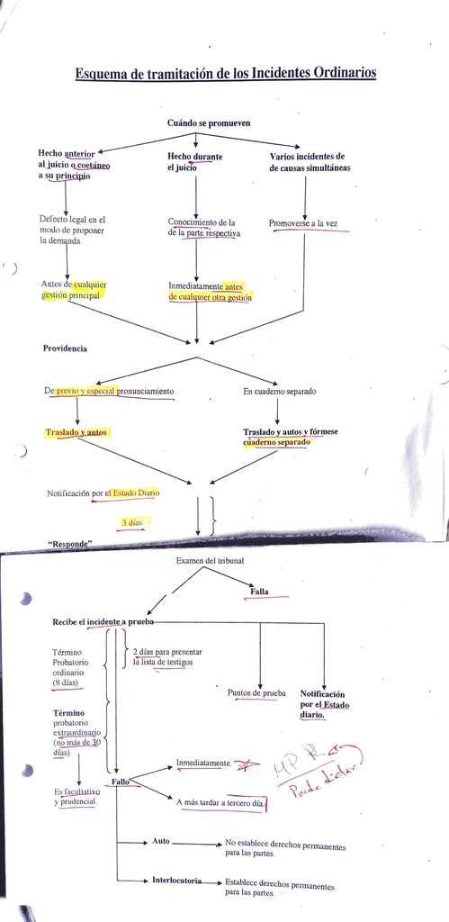

  Esquema Tramitación

  es la que se aplica tratándose de cualquier cuestión accesoria que merezca pronunciamiento especial por parte del TRB (un incidente) y que no tengan señalado una tramitación especial
  - promoción del incidente
  - resolverá de plano
    - no tiene conexión alguna, incidente inconexo
    - nace de un hecho anterior o coexistente y la parte realizó cualquier gestión principal antes (y no se trata de aquellas excepciones)
    - nace de un hecho acontecido durante el pleito y éste ha llegado en conocimiento de la parte y ella ha practicado cualquier gestión sin antes promoverlo
    - se promueven con posterioridad a otros cuyas causas existan simultáneamente
    - se trata de incidentes que se pueden resolver con los antecedentes que constan en el proceso o sean de pública notoriedad (debiendo consignarlo en el fallo), pudiendo rechazarlos o acogerlos de plano en este caso.
  - acogerá a tramitación

    cuando no se trate de una de las hipótesis anteriores, el cual se substanciará conforme a las ss. etapas
  - etapa de discusión
  - interposición del incidente o demanda incidental

    acto por el cual una de las partes solicita al TRB la resolución previa de una cuestión accesoria

    puede ser promovido por cualquiera de las partes, tanto directas como indirectas.

    es proveída (decreto) por el TRB confiriendo traslado a la parte contraria
  - contestación de la contraparte

    3 días, plazo de carácter individual y legal, para contestar

    vencido el plazo, art. 89, TRB procederá a recibir el incidente a prueba o bien fallarlo de plano (si a su juicio, no existe necesidad de prueba, pudiendo fundarse en hechos que consten en el proceso o sean de pública notoriedad, consignándolo en el fallo)
  - etapa de prueba
  - habiendo contestado o en su rebeldía, transcurrido los 3 días, TRB determinará si existen o no hechos controvertidos, substanciales y pertinentes.
  - constatando el TRB que si existen, recibirá el incidente a prueba, debiendo contener las ss. menciones:
    1. que se recibe el incidente a prueba
    2. determina los hechos controvertidos, substanciales y pertinentes. Ésta, se notificará por Eº diario a diferencia de la que recibe la causa a prueba que se notifica por cédula.
  - el término probatorio puede ser de 3 tipos:
    - ordinario

    dura 8 días, comienza a correr a partir de la notificación por eº diario. Durante este termino se puede rendir prueba en cualquier lugar, respecto a la testimonial deberá, la parte interesada, presentar la lista de testigos dentro de los 2 primeros días
    - extraordinario

    procede cuando el TRB lo decreta a petición de las partes, procediendo únicamente para rendir prueba en el lugar para el cual se concedió. Será determinado por el juez, sin superar los 22 días (art. 90.3 dice 30, pero se cuenta desde que se recibió el incidente a prueba, es decir, menos los 8 días)
    - especial

    es el que procede conforme a las reglas del juicio ordinario, por su carácter supletorio
  - las resoluciones que se pronuncie el TRB tanto como motivo de la recepción del incidente a prueba como de la ampliación del término probatorio son *inapelables* art. 90 inc. final
  - etapa de sentencia
  - etapa de sentencia

  vencido el término probatorio, se haya o no rendido prueba, aún que no lo pidan las partes el TRB fallará de inmediato o a más tardar dentro del 3º día. art. 91. No hay periodo de observaciones a la prueba ni citación a oír sentencia.
- reiteración de incidentes art. 88
  1. la parte que haya promovido y perdido 2 o más incidentes, deberá depositar en cuenta corriente del TRB la cantidad que éste fije
  2. lo hará de oficio cuando deseche el 2º incidente, que será entre 1 - 10 UTM como multa, si la parte no realiza el deposito el TRB lo tendrá por no presentado y se extinguirá el derecho a presentarlo nuevamente
  3. el monto será determinado en consideración a la actuación procesal de la parte y si observare mala fe podrá aumentar la cuantía de la multa hasta el duplo
  4. si la parte goza de privilegio de pobreza y el TRB considere que la parte está actuando de mala fe o con el claro propósito de dilatar el proceso podrá imponer al abogado o mandatario judicial la misma multa
  5. los incidentes que requieran de deposito señalado anteriormente se tramitarán en cuaderno separado y son inapelables
- incidentes especiales

  se trata de incidentes que tengan una tramitación especial o bien, que la ley imponga exigencia de requisitos particulares para su interposición
  - acumulación de autos

  tiene lugar siempre que se tramiten separadamente dos o más procesos que deban constituir un solo juicio y terminar por una sentencia, para mantener la continencia o la unidad de la causa
  - casos
    - mismas acciones o emanan de un mismo hecho
    - mismas personas, objetos o materia (aunque las acciones sean distintas)
    - siempre cuando la sentencia deba producir excepción de cosa juzgada en otro juicio
    - en los casos del procedimiento concursal de liquidación
  - cuestiones de competencia

  se trata de incidencias formuladas por las partes acerca de la falta de atribución del TRB requerido para conocer de un negocio jurídico. Se puede reclamar por dos maneras:
  - inhibitoria de incompetencia

    se concurre al TRB que no conoce del asunto y se estima competente, pidiendo que se dirija al que está conociendo del negocio para que se inhiba y se abstenga de seguir conociendo y le remita los antecedentes
  - declinatoria de competencia

    se solicita al TRB que está conociendo del asunto que decline de seguir conociéndolo y se declare incompetente
  - implicancias y recusaciones

  son ciertos hechos o circunstancias que pueden concurrir respecto de los jueces, auxiliares de la administración de justicia y de los peritos judiciales de los cuales
  - implicancia = la ley presume una falta de imparcialidad de la persona a quien le afecta para juzgar o intervenir en el proceso
  - recusación = faculta a la parte a quien podría perjudicar esta presunta falta de imparcialidad, para solicitar en el procedimiento correspondiente que se disponga una prohibición a un negocio específico
  - implicancias

    juez debe dejar constancia de inmediato apenas tome conocimiento del hecho constitutivo de una causal de implicancia
    - TRB unipersonal = se declarará inmediatamente inhabilitado para conocer del asunto
    - TRB colegiados = lo declarará al TRB que forma parte

    si no lo declara, la parte interesada deberá promover la incidencia
    - TRB competente
    - TRB unipersonal = ante el mismo
    - TRB colegiado = conocerá el TRB con exclusión del juez afectado
    - otro funcionario = conocerá el TRB ante el cual el funcionario debe intervenir
    - oportunidad

    deben ser planteadas antes
    - de realizar cualquier gestión relativa al fondo del asunto
    - o de que comience a actuar el afectado (juez)

    sin perjuicio que pueden promoverla con posterioridad en los ss casos
    - causal sobreviniente
    - se compruebe que la parte no tenía conocimiento de la existencia de los hechos que la constituyen
    - pagando multa si no se sostiene en alguno de los dos casos anteriores no mayor a 1 sueldo vital
  - recusaciones

    juez igualmente oº a dejar constancia en el proceso, tan pronto tenga conocimiento del hecho, los cuales, deberán ser puestos en conocimiento de la parte a la cual podría afectar la presunta falta de imparcialidad, para que promueva la incidencia de recusación dentro de 5 días, bajo el apercibimiento de tenérsela por renunciada si no lo hace. Durante dicho periodo el juez queda provisoriamente inhabilitado para intervenir en el asunto.
    - recusación amistosa

    puede la parte interesada concurrir ante el juez solicitándole que declare la recusación sin más trámite, exponiendo los fundamentos, si el TRB no estima pertinente, el interesado deberá deducir la incidencia.
    - TRB competente
    - contra juez = CA
    - M. CA = CS
    - M. CS = CA santiago
    - juez árbitro = juez de letras respectivo
    - otro funcionario = TRB que conoce del proceso en que le toca intervenir (al igual que en la implicancia)
    - oportunidad

    al igual que en la implicancia, antes de realizar cualquier actuación relativa al fondo del asunto, salvo que sea causal sobreviniente o probare no tener conocimiento

    de no hacerlo precluye su derecho, pero no se aplicará multa, dado que es de orden privado (este caso), y el titular puede renunciar
    - recusación de los abogados integrantes CA y CS

    pueden ser inhabilitados por vía de recusación sin necesidad de expresión de causa, por el solo hecho de presentarse el escrito o haciéndolo presente al relator de forma verbal (dos veces cada una de las partes), para lo cual se deberá pagar un impuesto fiscal especial en estampillas
  - el privilegio de pobreza

  es aquella institución en virtud de la cual la ley concede a las personas de escasos recursos el beneficio de quedar exentos de
  - pagos que normalmente se deben efectuar ya sea a abogados y procuradores, como a algunos auxiliares de la administración de justicia
  - así como otros desembolsos por concepto de consignación en los procedimientos

  Como incidente se debe entender como aquél por el cual una persona de escasos recursos solicita al TRB que lo declare pobre y que, como consecuencia de ello, quede exento del pago de honorarios, derechos, consignaciones.
  - las costas

  consisten en los gastos que deben solventar las partes a fin de poder hacer valer convenientemente sus derechos

  no son costas las consignaciones exigidas por la ley para prevenir gestiones maliciosas, la cual pasa a ser estimada como multa.

  por r. g. la parte que haya sido vencida totalmente en algún proceso o incidencia deberá soportar el pago de las costas,
  - excepciones a la r. g.:
    - privilegio de pobreza
    - cuando aparece que la parte ha tenido motivos plausibles para litigar
    - la ley establezca específicamente una norma diferente
  - apelación de las costas

    la parte afectada tanto por la condena o por su rechazo puede apelar sólo este aspecto (incluso si haya ganado en el proceso)
    - procedimiento
    1. la parte que haya obtenido en juicio deberá solicitar al TRB la tasación de las costas (en un escrito)
    2. función que podrá ser delegada en el secretario
    3. solo se considerarán costas aquellas útiles que consten en el proceso
    4. la resolución dispondrá la tasación y la regulación de las costas, que sean puestas en conocimiento de las partes y que se tengan por aprobadas si no fueren objetadas dentro del 3 día.
    5. si ninguna las partes se oponen a las tasas se tendrán por aprobadas, sin embargo, si se objeta el TRB puede resolver de plano o darle tramitación de incidente
    6. una vez ejecutoriada la resolución que falla el incidente de costas la parte en cuyo favor se dispuso el pago, podrá exigirlo por vía compulsiva o ejecutiva.
    7. art. 143 se debe entender que si bien el TRB regula las costas personas éstas se entienden sin perjuicio de los honorarios que se hayan pactado.
  - desistimiento de la demanda

  es aquel incidente especial por el cual la parte demandante de un proceso, después que la demanda haya sido legalmente notificada a la parte contraria, solicita al TRB que la tenga por desistida de la pretensión deducida
  - puede ser presentado en cualquier momento (antes que se haya concluido)
  - TRB proveerá el escrito confiriendo traslado a la parte contraria, la cual tendrá 3 días para oponerse, si no dice nada en ese periodo el TRB dictará una sentencia interlocutoria acogiendo el desistimiento
  - si se opone el TRB resolverá su prosecución, ya sea total o parcial
  - desistimiento de la reconvención

    se diferencia de la anterior en el sentido de que debe ser aceptado con citación y si la parte contraria se opone se conferirá traslado, la cual se resolverá de inmediato o en la sentencia definitiva
  - abandono del procedimiento

  es aquel incidente especial que consiste en la extinción de las actuaciones realizadas dentro de un procedimiento cuando todas las partes que figuran en él no han instado por su prosecución dentro del plazo de señala la ley (60 días) y que impide seguir con su substanciación

  dado que se encuentra tratado dentro de las Disposiciones comunes a todo procedimiento, tiene aplicación en cualquier tipo de procedimiento, salvo que la ley no lo permita o que la naturaleza del asunto lo impida.
  - excepción a la aplicación general del abandono
    - procedimientos concursales de liquidación
    - división o liquidación de herencias, sociedades o comunidades

  por r. g. solo puede ser hecha valer por el demandado, durante todo el juicio y hasta que se haya dictado sentencia ejecutoriada en la causa.

  en el caso de los procedimientos ejecutivos se puede, además solicitar el abandono, después de ejecutoriada la sentencia definitiva (o MEE que hace las veces de sentencia definitiva), dentro de 3 años.

  en el caso de que el procedimiento sea renovado y el demandado realice cualquier gestión que no tenga por objeto alegar su abandono se considerará renunciado este derecho art. 155
  - efectos
    - no se entienden extinguidas las acciones o excepciones de las partes
    - se pierde lo obrado
    - se pierde el derecho de hacerlo valer en un nuevo juicio
    - subsisten con todo su valor los actos y contratos de que resulten derechos definitivamente constituidos art. 156

  podrán volver a demandar sin perjuicio de las normas de prescripción del CC (declarado el abandono no se produce la interrupción civil
  - la nulidad procesal

  se trata de un incidente (cuestión accesoria de un proceso que requiere de un pronunciamiento especial del TRB), que versa sobre la nulidad de la relación procesal misma o de uno o más actos del procedimiento
  - ejemplos
    - nulidad que versa sobre la relación procesal misma

    es el caso de la nulidad de todo lo obrado por falta de emplazamiento, fundado en el caso de que no se haya notificado legalmente la demanda.
    - nulidad que versa sobre uno o más actos del procedimiento

    se produce cuando se solicita la nulidad de gestiones probatorias fundándose en la falta de notificación legal de la resolución que recibió la causa a prueba.
  - oportunidad

    la r. g. se deben promover en primera instancia hasta antes de que se notifique la sentencia definitiva a alguna de las partes
  - plazo

    dentro de 5 días contados desde que aparezca o se acredite que tuvo conocimiento del vicio, salvo que se trate de la **incompetencia absoluta del TRB** (puede plantearse en cualquier momento, y puede ser declarada de oficio por el TRB)
  - no pueden pedir la nulidad aquellos que
    - haya originado el vicio
    - concurrido a su materialización
    - haya convalidado expresa o tácitamente
  - vicio que producen la nulidad
    - en todos aquellos casos en que la ley establezca expresamente esa sanción
    - todos aquellos eventos en que exista algún vicio que irrogue a alguna de las partes un perjuicio sólo reparable con la declaración de nulidad
  - incidentes especiales de nulidad
  - incidente de nulidad de la notificación

    se entiende notificada desde el momento en que se notifique a la parte esa resolución que la declara nula

    si se trata de un TRB superior se entenderá notificada, desde que se notifique por estado diario del cúmplase
  - la nulidad de oficio

    siempre que
    - no se haya notificado legalmente a una de las partes (desasimiento del TRB)
    - que no haya precluido la oportunidad de las partes para solicitar la nulidad (por lo que no se ha convalidado el acto nulo)
  - la extensión de la nulidad procesal

    no necesariamente produce la nulidad de todo lo obrado con posterioridad, toda vez que es el juez el que debe señalar de forma precisa cuáles son los actos nulos en razón a su conexión con el acto anulado. Sin embargo, lo hará cuando el vicio afecta a la relación procesal misma como la falta de emplazamiento legal.

    lo anterior se debe entender sin perjuicio del recurso de casación en la forma, el cual , es otra forma de reclamar de la nulidad procesal

# 21. Medidas Cautelares, Prejudiciales y Precautorias

- Campo de aplicación:

  Conforme al art. 3 del CPC, son aplicables a cualquier tipo de procedimiento.
- Puede tener por finalidad:
  1. Obtener datos para la elaboración y redacción de la dda: 1-4 art. 273
  2. Procurar medios de prueba sobre hechos que puedan desaparecer: art. 273 n° 5, art. 281, 284 y 286
  3. Asegurar los resultados del juicio: art. 290.
- Medidas Prejudiciales:
  - TRB competente:

    La ley no señala, por lo que sería el TRB competente para conocer del juicio, teniendo presente lo que se tiene establecido para la prórroga de la competencia.
  - Tramitación:

    art. 289 “[estas diligencias] *pueden* decretarse sin audiencia […], salvo los casos en que expresamente se exige su intervención”.

    Por lo que, puede ser decretada *de plano*, una vez presentada la petición, estudiando los antecedentes aportados por la parte interesada, debiéndose notificar a la contraparte para que luego sea cumplida, o *con audiencia*, decretando traslado (dando nacimiento a un incidente).
- Medidas Precautorias:
  - Oportunidad:
    - aun cuando no esté contestada la dda
    - incluso después de COS (lo que es una excepción)
  - Son medidas precautorias ordinarias:
    - el secuestro
    - nombramiento de interventores
    - retención de bienes
    - prohibición de celebrar actos o cttos
  - Requisitos:
    - dte debe acompañar comprobantes que constituyan al menos presunción grave del derecho que se reclama
    - rendir caución
    - las circunstancias del caso no deben ofrecer seguridad del cumplimiento de la sentencia
    - la medida debe estar relacionada a bienes determinados y estrictamente necesarios
  - Tramitación:
    - traslado y tramitación de un incidente, que se ventila conforme a las reglas generales
  - Medidas Prejudiciales Precautorias
    - Requisitos:
      - los generales para toda medida prejudicial: expresar la acción que se pretende y sus fundamentos
      - comprobantes presunción grave de derecho que se reclama
      - motivos graves y calificados
      - determine el monto de los bienes sobre los cuales debe recaer
      - que se rinda caución suficiente
      - dte tiene plazo de 10 días (ampliables a 30) para presentar dda
      - pedir que se mantengan las medidas decretadas
      - será responsable de los perjuicios causados considerándose doloso si: a) no deduce dda en el tiempo, b) no pide que se mantengan las medidas, c) TRB no las mantiene, habiéndose pedido
  - Medidas Precautorias Extraordinarias

    art. 298: “[…] cuando lo estimare necesario y no tratándose de medidas expresamente autorizadas por la ley, exigir caución al actor para responder de los perjuicios que se originen”.
  - Medidas Precautorias Especiales

    art. 300 “Estas providencias no excluyen las demás que autorizan las leyes”

# 22. Del Juicio Ordinario

- Etapas

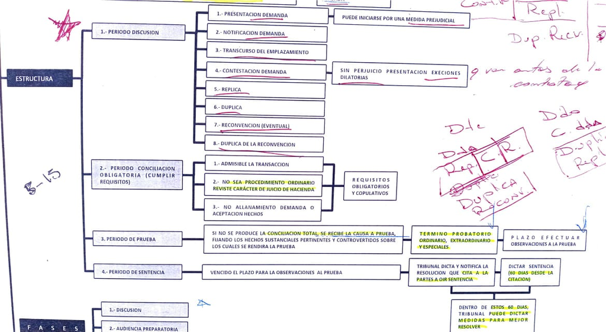

  Esquema

## Etapa de Discusión

- Formas de Iniciar el Juicio Ordinario (art. 253):
  - dda
  - medida prejudicial
- Importancia de la Dda:
  - es la base del juicio
  - se concreta las pretensiones del acto, limitando la sentencia
  - en base a la dda y su contestación será la prueba que se rinda
- Requisitos de la Dda:
  - Requisitos comunes a todo escrito:
    - suma
    - patrocinio y poder
  - Requisitos especiales de la dda:
    - art. 254
  - Omisión de los requisitos:
    - 1-3 art. 254 = juez puede de oficio no dar curso a la dda.
    - falta de algún requisitos legal en el modo de proponer la dda = excepción dilatoria de ineptitud del libelo
    - no designa domicilio = notificaciones que se deban hacerse por cédula se harán por estado diario
  - Forma de notifiación:
    - dte = por estado diario
    - ddo = personalmente si es la primera
  - Situaciones que pueden producirse una vez presentada:
    - no haya sido notificada = actor puede retirarla sin trámite alguno y se tiene por no presentada
    - dda fue notificada = dte puede desistirse de la misma en cualquier estado del juicio
    - dda notificada y antes que conteste = dte puede hacer en ella las ampliaciones o rectificaciones que estime conveniente, que se considerarán como una nueva dda para los efectos de su notificación.
  - Efectos de la dda:
    - queda abierta la instancia y el juez está obligado a conocer de las petición y tramitación de la causa
    - el actor manifiesta su intención (si la hubiere), de prorrogar tácitamente la competencia
    - en algunos casos se entiende que el derecho que se reclama existe desde la presentación de la dda = derecho de alimentos art. 331
- Efectos del Emplazamiento
  - relación procesal de las partes entre sí y con el TRB
  - crea la carga para el ddo de comparecer ante el juez e intervenir en el juicio
  - dte no puede hacer el retiro de la dda
  - juicio queda radicado
  - efectos de la sentencia se retrotraen a la época de la notificación de la dda
- Plazo de Emplazamiento
  - ddo es notificado en la comuna de funcionamiento del TRB = 15 días hábiles
  - ddo, en el mismo territorio jurisdiccional pero fuera de la comuna = 18 días hábiles
  - ddo fuera del territorio jurisdiccional = 18 días más tabla
  - pluralidad de dtes = se aumenta 1 día por cada 3 dtes sobre 10, que existan, no pudiendo superar 30 días
  - pluralidad ddos = término corre hasta que expire el último término parcial
- Actitudes del ddo:
  - excepciones dilatorias
  - aceptar dda
  - permanecer inactivo
  - defenderse
  - reconvenir
- Excepciones Dilatorias

  art. 303
  - n° 1 incompetencia de efectos permanentes.
    - absoluta = puede ser alegada en cualquier estado del juicio, irrenunciable y de orden público
    - relativa = sólo dentro del término de emplazamiento
  - n° 2 falta de capacidad
    - falta de capacidad del dte
    - falta de personería
    - falta de representación legal
  - n° 3 litis pendencia
    - respecto a las partes
    - causa de pedir
    - objeto pedido
  - n° 4 ineptitud del libelo
  - n° 5 beneficio de excusión
    - art. 2355 y 2357 CC
  - n° 6 toda aquella que se refiera a la corrección del procedimiento
- Oportunidad
  - deben oponerse todas en un mismo escrito, dentro del emplazamiento y antes de contestar la dda
- Tramitación
  - como incidentes
  - art. 306 se fallan a la vez, pero si figura la incompetencia, debe abstenerse de pronunciarse sobre las demás
  - la resolución que se pronuncia sobre ellas puede ser de dos tipos:
    - acoge las excepciones = dte no tiene plazo para corregir (abandono del procedimiento), efectuada las correcciones ddo tiene plazo de 10 días para contestar (cualquier lugar), apelable en el sólo efecto devolutivo
    - rechaza excepciones = ddo tiene 10 días para contestar, es apelable en el sólo efecto devolutivo
- Acepta la dda
  - TRB da traslado de la replica, el dte para la dúplica y luego COS, lo mismo ocurre cuando las partes piden que se falle el pleito sin más trámite.
  - se procede a COS en los ss casos:
    - ddo acepta llanamente
    - ddo no contradice en materia substancial y pertinente los hechos
    - las partes piden que se falle sin más trámite
    - vencido el plazo (de 10 días) para efectuar observaciones a la prueba
- Permanecer inactivo:
  - da lugar a rebeldía, la cual no tiene un carácter general para todo el juicio, es decir, sólo para esta diligencia
- Defenderse:
  - alegaciones o defensas y excepciones
  - las excepciones pueden ser:
    - perentorias
    - mixtas
  - Oportunidad:
    - rg. en el escrito de contestación de la dda
    - 16. excp.: excepciones anómalas
  - Tramitación:
    - en 1° inst. después de recibida la causa a prueba = como incidentes
    - en 1° inst. antes de recibir la causa a prueba = como incidente
    - en 2° inst. = como incidentes, pero se pronuncia en única instancia
- Contestación

  Contestación queda integrada la relación procesal y quedan fijados los hechos sobre los cuales van a recaer la prueba y la sentencia definitiva.
  - Requisitos:
    - Requisitos comunes a todo procedimiento: suma, patrocinio y poder
    - Requisitos especiales de la contestación (art. 309):
      - la designación del TRB
      - nombre domicilio, profesión u oficio del ddo
      - excepciones
      - enunciación precisa y clara, consignada en la conclusión, de las peticiones
  - Efectos:
    - queda integrada la relaición procesal
    - queda delimitada la cuestión controvertifa
    - se produce la prórroga de la competencia (si fuere el caso)
    - demandado no puede oponer excepciones dilatorias
- Reconvenir
  - Requisitos:
    - que el juez sea competente
    - debe formularla en el escrito de contestación de la demanda, siguiendo las reglas establecidas en los art. 254 y 261
    - debe estar sujeta al mismo procedimiento que la demanda
  - Tramitación:
    - art. 316 se substancia y falla conjuntamente con la dda principal
    - en contra de la reconvención las excepciones dilatorias se deben presentar dentro de 6 días
    - si es acogida el actor reconvencional debe subsanar los defectos dentro de 10 días
- Réplica y Dúplica

  Al demandante le corresponde la réplica y tiene 6 días para evacuarlo, luego de la contestación de la demanda

  El ddo tiene el mismo plazo para evacuar la dúplica.

  Con el escrito de dúplica queda terminado el período de discusión del juicio ordinario.

## Etapa de Conciliación

art. 262 salvo en: - juicio ejecutivo - gestiones relativas a la declaración del derecho legal de retención - citación de la evicción - juicios de hacienda - juicios sobre el estado civil de las personas - juicio de nulidad del matrimonio - juicio de separación de bienes

Una vez agotados los tramites de discusión y **siempre que hayan hechos substanciales, pertinentes y controvertidos**, el juez llamará a las partes a conciliación.

- Requisitos:
  - juicio civil
  - no se trate de aquellos juicios exceptuados por ley
  - que recaiga sobre derechos susceptibles de transacción
  - que no se trate de los casos del art. 313 en que procede COS
- Oportunidad:
  - una vez agotado los trámites de discusión
  - en cualquier estado de la causa una vez evacuado el trámite de contestación
- Tramitación:
  - TRB cita a audiencia a las partes, no antes de 5 días ni más allá de 15 días. Si el procedimiento contempla una audiencia para la contestación, se realizará en ella
  - notificación por cédula (ordena la comparecencia de las partes)
  - la conciliación sólo produce efecto respecto de las partes que concurrieron
  - art. 263 juez obra como amigable componedor y trata de obtener un avenimiento total o parcial
  - Si este comparendo es rechazado o no se lleva a cabo, el secretario certificará el hecho de inmediato, entregando los autos al juez para su examen a fin de determinar si existen hechos substanciales, pertinentes y controvertidos para recibir la causa a prueba
  - de la conciliación se levanta acta, con las especificaciones del arreglo y será firmado por el juez, las partes y el secretario. Dicha acta, se estima como sentencia ejecutoriada.

## Etapa de Prueba

No tratándose de los casos señalados en el art. 313, el TRB debe examinar por sí mismos los autos y si estima que hay o puede haber controversia sobre algún hecho sustancial y pertinente en el juicio recibirá la causa a prueba, fijando en la misma resolución los hechos sustanciales, pertinentes y controvertidos sobre los que debe recaer.

- Requisitos:
  - controversia
  - debe referirse a hechos
  - los hechos sobre los cuales recae la controversia deben ser **substanciales y pertinentes**
- Naturaleza Jurídica

La resolución que recibe la causa a prueba es una sentencia interlocutoria (de 2° grado) que resuelve un trámite que va a servir de base para el pronunciamiento de otra sentencia.

- Contenido de la Resolución:
  - orden de recibir la causa a prueba
  - fijación de los puntos de prueba
  - eventualmente puede contener la fijación de las audiencias para que las partes rindan prueba testimonial
- Recursos:
  - reposición

    dentro del 3° día art. 319.
  - apelación

    Sólo en subsidio del recurso de reposición en caso de que este no sea acogido por el TRB.
- Ampliación de la Prueba

  art. 321 en los ss casos:
  - cuando dentro del término ocurre algún hecho substancialmente relacionado con el hecho que se ventila
  - cuando la ampliación se refiere a hechos verificados y no alegados antes de recibirse a prueba la causa tal que jure el que los aduce que sólo entonces han llegado a su conocimiento

  Se tramitan como incidente en cuadernos separados.
- Cuestiones sobre la prueba testimonial

  Se debe presentar lista de testigos y minuta de los puntos de prueba, dentro de los 5 días desde: a) la primera notificación de la resolución que se refiere el art. 318 cuando no se haya pedido reposición, b) desde la notificación por estado diario de la resolución que se pronuncie sobre la última solicitud de reposición, cuando se haya pedido reposición

  En el caso de que no se presente la lista de testigos la sanción es que no se podrá rendir prueba testimonial, en el caso de que no se presente minuta sobre los puntos de prueba, su sanción es, conforme a la jurisprudencia, que los testigos sólo declararan al tenor de los hechos controvertidos fijados por el juez.
- Término Probatorio
  - Características:
    - término fatal para rendir la prueba testimonial
    - puede ser legal, judicial o convencional
    - es común
    - improrrogable
    - puede ser reducido por acuerdo unánime de las partes (plazo convencional)
    - no se suspende en caso alguno, salvo acuerdo de las partes
    - dentro de él se debe solicitar toda diligencia probatoria que no se haya solicitado con anterioridad
    - todo incidente debe ser substanciado en cuaderno separado
- Clases
  - ordinario

    En el cual se puede rendir prueba en cualquier punto de la República o fuera de ella, art 334.
  - extraordinario

    Vencido el término ordinario sólo puede rendirse prueba en aquellos lugares para los cuales se haya otorgado el aumento extraordinario, el cual empieza a correr una vez que se extingue el término ordinario Diferencias respecto si el término extraordinario es rendido dentro o fuera del territorio de la República:

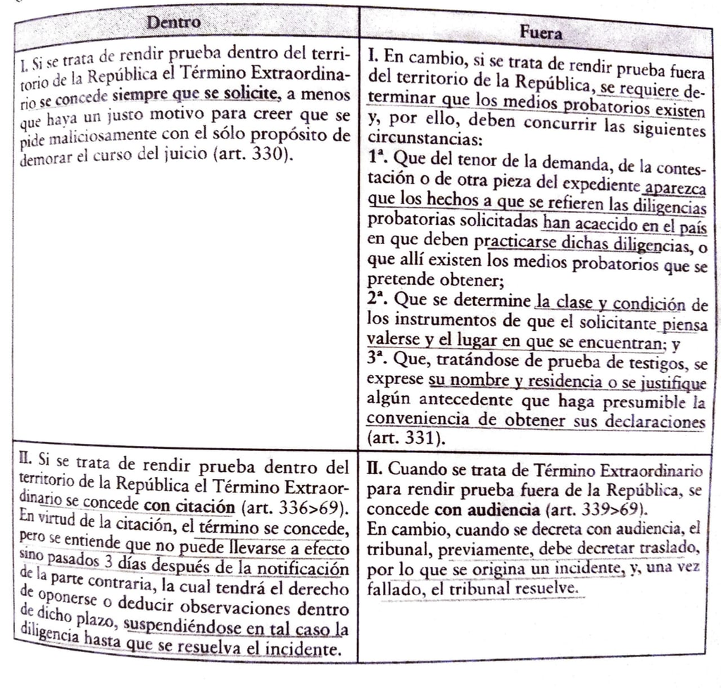

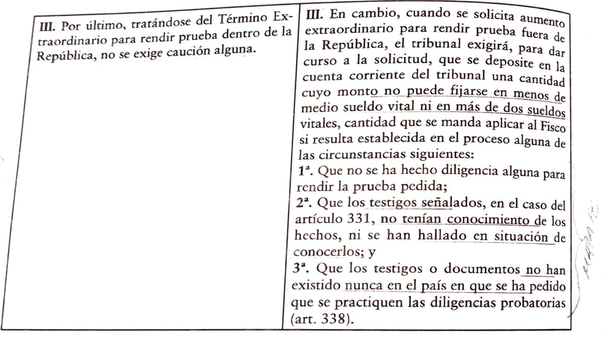

    Sanción: art. 337
  - especial

    art. 339, podrá, el TRB, otorgar un término especial:
    - por el número de días que haya durado el entorpecimiento
    - sólo en aquél lugar a que dicho entorpecimiento se refiera

    Son ejemplos:
    - inc. final art 339
    - art. 340 (respecto de diligencias solicitadas en tiempo hábil)
    - art. 340 (inasistencia del juez)

### Los Medios de Prueba en Particular

- Instrumento Público
  - Iniciativa:
    - p rg. a iniciativa de parte
    - p excp. de parte del TRB en las MPR
  - Formas de acompañar:
    - documentos que la parte tiene en su poder:
      - 1. público = con citación, 3 días para objetarlo
      - si se acompaña en la dda = término de emplazamiento
      - 1. en lengua extranjera = 6 días
    - 1. que esté en mandos de la contraria o tercero:
      - debe tener relación directa con la cuestión debatida y no revestir el carácter de secreto
      - costos por parte de la parte solicitante
      - sanción por incumplimiento: multas que no excedan de 2 sueldos vitales y arrestos hasta por 2 meses
  - Oportunidad:
    - cualquier estado del juicio **hasta el vencimiento del término probatorio** en 1° inst. y **hasta la vista de la causa** en 2° inst.
  - I. Otorgados Fuera de Chile
    - art. 345 deben ser presentados legalizados
    - art. 345 bis apostillados respecto a aquellos Estados Parte de dicho tratado
  - Valor Probatorio I. Público
    - entre las partes
      - hacen plena prueba respecto a:
        - haberse otorgado por las personas y de la manera que se expresa
        - fecha
        - declaraciones dispositivas
      - no hacen plena prueba:
        - declaraciones enunciativas, salvo que tengan relación directa con lo dispositivo
      - respecto a terceros:
        - fecha
        - hecho de haberse otorgado
        - declaraciones dispositivas
  - Impugnación
    - por falta de autenticidad
    - por nulidad
    - por falta de verdad de las declaraciones
  - Forma de impugnación:
    - vía ppal.: procedimiento declarativo
    - vía incidental: se impugna dentro del término de citación, por haberse acompañado dicho i.
- Instrumentos Privados

  Solamente tienen valor probatorio si son reconocidos en juicio. Ver art. 346 respecto de los i. privados que se tienen por reconocidos.

# 23. Juicio Sumario

# 24. Procedimiento de Menor Cuantía

# 25. Acciones Posesoria

# 26. Juicios de Hacienda

# 27. Juicios ante Árbitros y Particiones

# 28. Los Actos Judiciales no Contenciosos

# 29-36. Juicio Ejecutivo

# 37. Los Recursos

# 38. Derecho Procesal Penal

# 39. Sujetos Procesales

- Son Sujetos Procesales
  - El tribunal u órgano jurisdiccional
  - El ministerio público
  - La policía
  - El imputado
  - La defensa
  - La víctima
  - El querellante

## Tribunales

- Forma de actuar de los Tribunales

  La regla general es que las resoluciones se deben dar en audiencias con la participación de todos los intervinientes, por excepción puede resolver sin audiencia (como en el caso de la inadmisibilidad de una querella) o sin la participación de todos los intervinientes como es el caso de lo establecido en el artículo 236.
- Organización
  - Comité de jueces, aprueba forma de distribución de causas
  - Juez presidente, 2 años, correcto funcionamiento del TRB
  - Administrador general, funcionario auxiliar, organiza y controla gestión administrativa
  - Subadministrador, apoya gestión administrador
  - Unidades administrativas, TRB se organizan para su cumplimiento eficaz y eficiente
    - Sala, organización y asistencia de las audiencias
    - Atención al publico
    - Servicio, soporte técnico
    - Administración de causas, manejo y registro, fechas y salas audiencias, ingreso, su jefe autoriza mandato y efectúa certificaciones
    - Testigos y peritos, sólo en TOP, atención información y orientación a testigos y peritos citados

## Policía

- Entrada y registro en lugares de libre acceso público La policía puede efectuar registro.
- Entrada y registro en lugares cerrados Se podrá entrar al mismo y proceder al registro, siempre que su propietario o encargado consintiere expresamente, causando el menor daño y molestias posibles, entregando un certificado que acredite el hecho del registro y la identificación de los funcionarios. Si no permitiere la entrada la policía tomará las medidas para evitar la posible fuga del imputado y el fiscal solicitará autorización.
- Entrada y registro en lugares cerrados sin autorización u orden cuando exista:
  - llamadas de auxilio
  - otros signos evidente de delito
  - indicio de destrucción de objetos y documentos de cualquier clase que pudieren haber servido o haber servido o destinados al delito Comunicándose inmediatamente al fiscal terminado el registro y levantándose un acta que deberá ser enviada dentro de las 12 hrs, que también será entregada al propietario o encargado del lugar. En el caso del abigeato, podrá ingresar cuando existan indicios o sospechas de que se está perpetrando dicho ilícito, siempre que las circunstancias hagan de temer que la demora en obtener la autorización del propietario o juez facilitaría la concreción del mismo o su impunidad.
- Entrada y registro en lugares especiales art.208 son lugares especiales = religiosos, edificios en que funcione alguna autoridad pública, o recinto militar. Comunicándose el fiscal con 48 horas con anticipación conteniendo señas de lo que hubiere de ser objeto del registro y las personas que acompañarán, invitando a la autoridad que asista, a menos que con dicha comunicación se pudiera frustrar la diligencia. Sin embargo, si implican:
  - documentos
  - información
  - elementos

  Cuyo conocimiento pudiere afectar la *seguridad nacional*, la persona a cargo del recinto informará de inmediato y fundadamente al **Ministro de Estado** correspondiente, quien podrá, si lo estima conveniente, oficiará al fiscal manifestando su oposición. En el caso que el fiscal persista deberá remitir los antecedentes al fiscal regional, quien si comparte la decisión, deberá solicitar a la **Corte Suprema** que resuelva la controversia. En estos casos, se aplicará el secreto (art.182) a dichos antecedentes. Es decir, disponiendo que dichas actuaciones sean mantenidas en secreto respecto del imputado o de los demás intervinientes por 40 días, ampliables, cuando lo considere necesario para la eficacia de la investigación. Rigiendo en lo pertinente el art. 19 sobre *requerimientos de información, contenido y fomalidades*. El cual señala que las autoridades deben realizar las diligencias sin demora, pero que tratándose de información de carácter secreto se atenderá a lo prescrito por las leyes respectivas o, en su defecto, adoptándose las precauciones de que dicha información no será **divulgada**. En tal situación, si la autoridad se retardare en el envío de los antecedentes bajo el pretexto del carácter de secreto o reservado, el fiscal deberá remitir los antecedentes al fiscal regional, que si compartiere la decisión, solicitará a la Corte de Apelaciones, previo informe de la autoridad, que resuelva la controversia. En el caso de que la publicidad pudiera afectar la seguridad nacional será resuelta por la Corte Suprema. Aun cuando rechace el requerimiento, podrá ordenar que se suministren al ministerio público o al tribunal los datos que le parecieren necesarios para la adopción de decisiones relativas a la investigación o para el pronunciamiento de resoluciones judiciales.
- Entrada y registro en lugares que gozan de inviolabilidad diplomática Juez pedirá, por conducto del Ministerio de Relaciones Exteriores, su consentimiento al **jefe de misión** para que lo conteste dentro de 24 horas. De no hacerlo lo reiterará al Ministro de Relaciones Exteriores, absteniéndose de autorizar la entrada, sin perjuicio de poder autorizar la adopción de medidas de vigilancia. Casos urgentes = juez puede solicitar la autorización directamente o por intermedio del fiscal.
- Entrada y registro en lugares consulares se deberá recabar el consentimiento del jefe de la oficina consular o de una persona que él designe, o del jefe de misión diplomática, procediendo como el caso anterior.

## Defensa

Tener presente art 103 bis, el cual señala sanciones al defensor que se ausentare, renunciare, o abandonare injustificadamente audiencias de: + APJO (dentro de los 7 días anteriores) + JO (dentro de los 10 días) + JA Suspensión del ejercicio de la profesión entre 15 a 60 días. Es importante recordad el art. 103 que señala que la ausencia del defensor en cualquiera de las actuaciones que la ley exigiere expresamente su presencia produce **nulidad** de la misma.

## Querellante

- la víctima, su representante legal o su heredero testamentario
- cualquier persona (delitos terroristas, por funcionarios públicos que afecten derechos garantizados por la CPR, probidad pública)
- órganos y servicios públicos cuando sus propias leyes orgánicas los autorice.

# 40. Clases de Acciones

# 41. Estructura y Procedimiento Ordinario

# 42. Medidas Cautelares y Sistema Probatorio

# 43. Salidas Alternativas y Juicio Oral

# 44. Nulidades Procesales

# 45. Conclusión de la Etapa de Investigación

# 46. Sobreseimiento

# 47. Etapa Intermedia y Preparación del Juicio Oral

# 48. Etapa de Juzgamiento

# 49. Desarrollo del Juicio Oral

# 50. Sentencia Definitiva

# 51. Recursos en el Nuevo Proceso Penal

- Reclamaciones administrativas ante MP

  Tener presente art. 32 letra b de la LOCMP, la cual establece como atributo del FR la de “conocer y resolver las reclamaciones que cualquier interviniente en un procedimiento formulare respecto de la actuación de un fiscal adjunto que se desempeñe en la Fiscalía Regional a su cargo”, las cuales según el artículo 33 “deberán ser presentadas por escrito al FR, quien deberá resolverlas, también **por escrito**, **dentro de 5 días hábiles**”.

# 52. Procedimientos Especiales

# 53. Ejecución de las Sentencias Condenatorias y Medidas de Seguridad

# 54. Procedimientos Especiales de Trabajo y Familia

Procedimientos de doble audiencia. Estructuras general de estos procedimientos. Principios Procesales En Los Procedimientos De Audiencias. Similitudes y diferencias. El procedimiento se estructura sobre la base de dos audiencias: una de carácter preparatoria y otra de juicio propiamente tal. La finalidad de la audiencia preparatoria es despejar todas las cuestiones previas a la producción de la prueba. Se trata de un procedimiento predominantemente oral. Respecto a la competencia de los TRB laborales, el factor cuantía determina el procedimiento aplicable, monitorio o el procedimiento de aplicación general.

# 55. Procedimiento de Aplicación General del Trabajo

- Principios formativos del Procedimiento Laboral

  Art. 425, los procedimientos del trabajo serán orales, públicos y concentrados. primarán en ellos los principios de la inmediación, impulso procesal de oficio, celeridad, buena fe, bilateralidad de la audiencia y gratuidad. Respecto al principio de impulso procesal de oficio tener presente el art. 429 que señala que una vez reclamada su intervención, el TRB actuará de oficio, decretando pruebas, adoptando las medidas tendientes a evitar la paralización del proceso, no siendo aplicable el abandono del procedimiento.

  Organización. Estructura. Competencia (ART. 420 C. del Trabajo). Demanda, contestación, medios de prueba, audiencia preparatoria, audiencia de juicio, valoración de la prueba. Recursos ordinarios en el procedimiento. Ejecución de las sentencias

# 56. Procedimiento Monitorio

Es el procedimiento aplicable respecto aquellas contiendas cuya cuantía sean igual o inferior a diez ingresos mínimos mensuales, sin considerar en su caso, los aumentos que hubiere lugar por aplicación de los inc. 4 y 7 del art. 162, y de las contiendas a que se refiere el art. 201 del CT El Procedimiento monitorio y el de tutela labor se tratan de dos procedimientos especiales. Art. 496 A 502 C.DEL TRABAJO

# 57. Procedimiento de Tutela Laboral

Art. 485 y siguientes. Protección constitucional. Causales, finalidades, Comparecientes individuales y colectivos, capacidades, indicios y valoración de la prueba, estructura del juicio. Causal de indemnidad.

# 58. Tramitación ante los Tribunales de Familia

Ley 19.968. Competencia de los Tribunales de Familia. Jurisdicción. Mediación. Estructura del juicio. Medios de prueba. Recursos.

# 59. Del Recurso de Nulidad en los Procedimientos del Trabajo y de Familia

Concepto, descripción, finalidad, carácter del recurso. Objetivos. Similitudes.